# Lab05: Regression Analysis of a Heterogeneous and Spatially Distributed Dataset

Author

Shiu-Ting Ling

**Handout date:** Monday, March 30, 2026

**FIRM DUE DATA:** Saturday, April 18, 2026

**Submission Format:** Submit your lab as R Markdown document `Lab05YourName.rmd` to eLearning’s *SumitLab05* link in the **Labs** folder. Put your name behind the author’s keyword into the header of the YAML header of the Markdown file. Make sure that your R Markdown document renders properly into an `html` document. Otherwise, we will *not* be able to grade your lab!

*This lab counts 13 points towards your final grade.*

Your lab answer has obtained *xx* out of 13 points?

# Preamble

You will build a spatial regression model to analyze the 2018 American Community Survey *percent of the civilian non-institutionalized population with health insurance* in the *census tracts* of Dallas County. You need to [i] formulate common sense hypotheses, [ii] explore the data and build an appropriate regression model as well as [iii] perform proper model diagnostics, which lead to reasonably interpretable final model. Furthermore, you investigate [iv] the presence of potential heteroscedasticity and [v] a build a spatial regression model, perhaps, incorporating identified heteroscedasticity. You are expected to justify, document, interpret and/or comment each step of your analysis.

# Theme Notes on Health Insurance in the U.S.A.

The civilian non-institutionalized population (CNIP) is frequently used in health insurance studies. It comprises of the population 16 years and older, who are **not** inmates of institutions (penal, mental facilities, homes for the aged), and who are not on active duty in the Armed Forces. Inmates of institutions as well as in the persons in the Armed Forces are by default health insured. This leaves the CNIP *to choose signing up for health insurance* or not. Furthermore, persons 65 and older or persons with disabilities can sign-up at minimal costs for one of Social Security’s *Medicare* or *Medicaid* health insurance plans.

# Data Files and Preparation

The key variables can be found in the `tractShp` data object in the package `TexMix`. These variables are augmented by the 2018 census variables in the file `HealthInsuranceDallas2018.xlsx` and linked to `tractShp` in the data preparation section below.

## Additional Variables

Note the use of *upper* and *lower* case letters in the variable names.

| Name | Description |
| --- | --- |
| `TRACT` | Factor with the Census Tract ID |
| `CNPop` | Civilian non-institutionalized population (CNIP) |
| `CNwHI` | CNIP with health insurance |
| `CNwPriHI` | CNIP with private health insurance |
| `CNwPubHI` | CNIP with public health insurance |
| `CNnHI` | CNIP without health insurance |
| `CNnHi_19` | CNIP without health insurance < 19 years old |
| `CNwDis` | CNIP with disability |
| `CN_18` | CNIP < 18 years old |
| `CNwDis_18` | CNIP with disability < 18 years old |
| `CN18_64` | CNIP 18 to 64 years old |
| `CNwDis18_64` | CNIP with disability 18 to 64 years old |
| `CN65` | CNIP 65 years and older |
| `CNwDis65` | CNIP with disability 65 years and older |

## Data Preparation

The code chunk below outlines:

[b] The *exclusion of 2 airport tracts* leaving 527 census tracts with valid civilian non-institutionalized population.

[c] The calculation of your dependent variable *percent of the civilian non-institutionalized population with health insurance* in the variable `tractShp$PctCNwHI`.

[d] The addition of row-names to `tractShp@data` starting with the value 1.

[e] The map pattern of the dependent variable `PctCNwHI`,

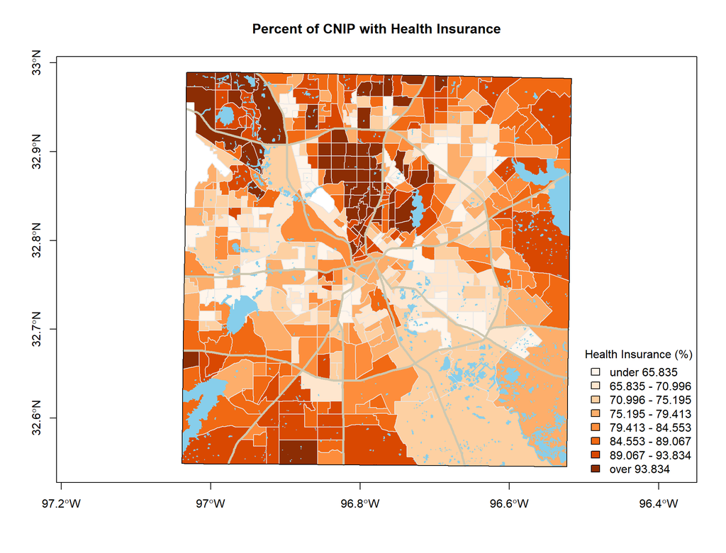

```r
data("tractShp")
tractShp$TRACT <- as.numeric(as.character(tractShp$TRACT))                    # Convert factor to numeric

## Import support data
HealthInsurance <- read_excel("HealthInsuranceDallas2018.xlsx")
HealthInsurance$TRACT <- as.numeric(as.character(HealthInsurance$TRACT))

## Merge by TRACT into tractShp
tractShp <- sp::merge(tractShp, HealthInsurance, by="TRACT")

## Exclude both airport tracts leaving 527 valid tracts
tractShp <- tractShp[tractShp$TRACT!=48113980000 & tractShp$TRACT!=48113980100, ]

## Calculate % of CNIP with healht insurance
tractShp$PctCNwHI <- tractShp$CNwHI/tractShp$CNPop * 100

## Add row-names 1:527 to data-frame
rownames(tractShp@data) <- 1:nrow(tractShp@data)

## Map dependent variable PctCNwHI including NAs
mapColorRamp(tractShp$PctCNwHI, tractShp, breaks=8, legend.pos="bottomright",
             map.title = "Percent of CNIP with Health Insurance",
             legend.title = "Health Insurance (%)")
plot(lakesShp, col="skyblue", border="skyblue",add=TRUE)
plot(hwyShp, col="cornsilk3", lwd=3, add=TRUE)
plot(bndShp, border="black", add=TRUE)
box()
```

```r
summary(tractShp)
```

```
Object of class SpatialPolygonsDataFrame
Coordinates:
        min       max
x -97.03839 -96.51687
y  32.54521  32.98933
Is projected: FALSE
proj4string : [+proj=longlat +ellps=GRS80 +no_defs]
Data attributes:
     TRACT                 ID             AREA               DES3NEIG
 Min.   :4.811e+10   Min.   :10113   Min.   : 0.1091   No        :513
 1st Qu.:4.811e+10   1st Qu.:29400   1st Qu.: 0.5563   Park/Urban:  2
 Median :4.811e+10   Median :47750   Median : 0.9834   RedBird   :  8
 Mean   :4.811e+10   Mean   :48011   Mean   : 1.7011   UniCor    :  4
 3rd Qu.:4.811e+10   3rd Qu.:70285   3rd Qu.: 1.7475
 Max.   :4.811e+10   Max.   :86780   Max.   :52.3683

 FOODDES         CITYPERI      LANDAREA         WATERAREA
 no :513   CityDallas:281   Min.   : 0.1099   Min.   :0.000000
 yes: 14   East      : 74   1st Qu.: 0.5571   1st Qu.:0.000000
           North     : 51   Median : 0.9789   Median :0.000000
           ParkCities:  8   Mean   : 1.6293   Mean   :0.070843
           South     : 33   3rd Qu.: 1.6267   3rd Qu.:0.004106
           West      : 80   Max.   :51.6896   Max.   :4.220209

     POPDEN             BUYPOW             HHMEDINC        PCTDAYPOP
 Min.   :   82.61   Min.   :4.855e+06   Min.   : 14754   Min.   :13.96
 1st Qu.: 2363.97   1st Qu.:6.158e+07   1st Qu.: 39048   1st Qu.:26.96
 Median : 3708.51   Median :9.385e+07   Median : 51139   Median :33.11
 Mean   : 5231.91   Mean   :1.260e+08   Mean   : 62459   Mean   :38.77
 3rd Qu.: 5382.85   3rd Qu.:1.455e+08   3rd Qu.: 72096   3rd Qu.:44.88
 Max.   :80322.40   Max.   :1.125e+09   Max.   :250001   Max.   :99.81

     DAYPOP          NIGHTPOP          MALE          FEMALE         MEDAGE
 Min.   :   162   Min.   :   75   Min.   :  22   Min.   :  53   Min.   :20.30
 1st Qu.:  1596   1st Qu.: 3376   1st Qu.:1660   1st Qu.:1687   1st Qu.:29.70
 Median :  2491   Median : 4632   Median :2236   Median :2365   Median :33.10
 Mean   :  4439   Mean   : 4843   Mean   :2387   Mean   :2456   Mean   :34.55
 3rd Qu.:  4056   3rd Qu.: 6090   3rd Qu.:2982   3rd Qu.:3114   3rd Qu.:38.60
 Max.   :127820   Max.   :18048   Max.   :8733   Max.   :9315   Max.   :65.70

```

[output cut: 96 more lines]

```
     CNwDis         CN_18          CNwDis_18         CN18_64
 Min.   :   0   Min.   :   0.0   Min.   :  0.00   Min.   :   27
 1st Qu.: 254   1st Qu.: 744.5   1st Qu.:  9.00   1st Qu.: 2106
 Median : 411   Median :1193.0   Median : 30.00   Median : 2886
 Mean   : 464   Mean   :1303.7   Mean   : 44.64   Mean   : 3079
 3rd Qu.: 624   3rd Qu.:1742.0   3rd Qu.: 64.00   3rd Qu.: 3820
 Max.   :2057   Max.   :5340.0   Max.   :265.00   Max.   :11893

  CNwDis18_64          CN65           CNwDis65        PctCNwHI
 Min.   :   0.0   Min.   :  11.0   Min.   :  0.0   Min.   : 42.45
 1st Qu.: 124.0   1st Qu.: 277.0   1st Qu.: 79.0   1st Qu.: 71.00
 Median : 215.0   Median : 441.0   Median :146.0   Median : 79.41
 Mean   : 246.9   Mean   : 489.8   Mean   :172.5   Mean   : 79.46
 3rd Qu.: 330.5   3rd Qu.: 635.0   3rd Qu.:236.0   3rd Qu.: 89.07
 Max.   :1375.0   Max.   :1975.0   Max.   :869.0   Max.   :100.00
```

Be careful, from the summary statistics you see that some variables still have a few `NA`s for the 527 remaining census tracts.

# Analysis Tasks

## Selection of Independent Variables (1 point)

[a] Identify 4 to 6 potential independent **metric variables** and one **factor** that you expect to influence the spatial pattern in the proportion of the civilian non-institutionalized population with health insurance. Avoid highly redundant variables.

### The selected independent Variables

Five metric variables and one factor variable are selected to explain the spatial pattern of the percent of the civilian non-institutionalized population with health insurance (`PctCNwHI`) across Dallas County census tracts. The selected metric variables are `PERCAPINC`, `PCTUNIVDEG`, `PCTUNEMP`, `MEDAGE`, and `PCTHISPAN`. The selected factor variable is `CITYPERI`. These variables are chosen to capture the economic, demographic, and geographic dimensions of health insurance coverage, while avoiding highly redundant variables such as `PCTNOHINS`, which is mathematically equivalent to the complement of the dependent variable.

[b] Formulate common-sense hypotheses **why** and **which direction**, i.e., increasing or decreasing, the potential metric variables will influence the `PctCNwHI` and complete the table below.

*Your answer goes here*

### The common-sense hypotheses of metric Variables

| Variable | Description | Rational | Direction |
| --- | --- | --- | --- |
| `PERCAPINC` | Per capita income | Census tracts with higher per capita income have residents who are better able to afford private health insurance premiums. | Increasing |
| `PCTUNIVDEG` | % population with university degree | A higher share of college-educated residents is associated with greater awareness of the importance of health insurance and better access to employer-sponsored plans. | Increasing |
| `PCTUNEMP` | % unemployed in labor force | Higher unemployment means fewer residents have access to employer-provided health insurance, reducing overall coverage rates. | Decreasing |
| `MEDAGE` | Median population age | Older populations are more likely to qualify for Medicare or Medicaid at minimal cost, increasing the share of insured residents. | Increasing |
| `PCTHISPAN` | % Hispanic population | A larger Hispanic population share is associated with lower insurance rates, partly due to immigration status restrictions on eligibility and language barriers in the enrollment process. | Decreasing |

[c] Discuss why and how you expect the selected **factor** will influence the `PctCNwHI`.

*Your answer goes here*

### The common-sense hypotheses of factor Variables

The factor variable `CITYPERI` distinguishes census tracts by their location within Dallas County, including the city of Dallas, Park Cities, and the northern, eastern, southern, and western peripheral areas. It is expected that health insurance coverage rates will vary systematically across these geographic subdivisions, even after controlling for the metric variables above.

Specifically, tracts in Park Cities and northern Dallas are predominantly higher-income and predominantly white neighborhoods, and are therefore expected to show higher insurance rates. In contrast, southern and western Dallas tracts tend to have larger Hispanic and lower-income populations, suggesting lower coverage rates. The city of Dallas core may exhibit intermediate rates due to its mixed socioeconomic composition. Therefore, `CITYPERI` is expected to capture residual geographic variation in health insurance access that is not fully explained by the metric variables alone.

## Visual Exploration and Transformation (2 points)

Explore visually the variables using either a scatter-plot matrix or box-plots:

- Discuss the relationship between the `PctCNwHI` and the independent variables.
- Discuss the relationship between the `PctCNwHI` and the factor variable.
- Discuss the outstanding relationship among the independent variables.
- Discuss the necessity of variable transformations and shift parameters with `car::symbox( )` function and when appropriate with a preference of the log-transformation.
- If necessary remove any problematic census tracts from `tractShp`.

*Your answer goes here*

### Identification and Removal of Problematic Census Tracts

To identify census tracts with potentially unreliable estimates, all 527 tracts are sorted by their civilian non-institutionalized population (`CNPop`) in ascending order, and the 10 smallest tracts are inspected. A separate check is then performed on the smallest tract to retrieve its `PctCNwHI` value and geographic region.

```r
## Check CNPop for each tract - sorted from smallest to largest (top 10)
head(tractShp@data[order(tractShp@data$CNPop), c("TRACT", "CNPop")], 10)
```

```
          TRACT CNPop
47  48113014002    62
261 48113001701   452
105 48113008603   747
48  48113013713   833
318 48113007826   987
304 48113013104  1002
306 48113007823  1030
456 48113018403  1178
107 48113003400  1245
108 48113004000  1296
```

```r
## Inspect the smallest CNPop tract
tractShp@data[tractShp@data$TRACT == 48113014002,
              c("TRACT", "SeqId", "CNPop", "PctCNwHI", "CITYPERI")]
```

```
         TRACT SeqId CNPop PctCNwHI CITYPERI
47 48113014002    47    62      100    North
```

The results show that tract **48113014002 (`North` region)** has an extremely small `CNPop` of only 62 persons, and its corresponding `PctCNwHI` is 100%. This value is statistically unreliable — with such a small population base, the estimated health insurance rate is highly sensitive to even a single person changing their insurance status, and therefore cannot be considered a meaningful representation of the tract’s true coverage rate. Furthermore, a `PctCNwHI` of exactly 100% is a boundary value that may cause numerical issues in subsequent log-odds or regression analyses. For these reasons, tract 48113014002 is removed jointly from both the geographic layer and the attribute table of `tractShp`, leaving **526 census tracts** for all subsequent analyses.

The second smallest tract **48113001701** (`CNPop` = 452) is considered acceptable and is retained in the dataset.

```r
## Remove tract 48113014002 (SeqId=47, CNPop=62, PctCNwHI=100%)
## Reason: extremely small CNPop leads to unreliable PctCNwHI estimate
tractShp <- tractShp[tractShp$TRACT != 48113014002, ]

## Update row-names after removal
rownames(tractShp@data) <- 1:nrow(tractShp@data)

## Confirm removal
cat("Remaining tracts after removal:", nrow(tractShp@data), "\n")
```

```
Remaining tracts after removal: 526
```

**Tract 48113014002** is removed from `tractShp` using row subsetting. Since `tractShp` is a `SpatialPolygonsDataFrame` object, this operation simultaneously removes the tract from both the geographic polygon layer and the attribute table, ensuring consistency between the spatial and attribute data. The row names are subsequently reset to run from 1 to 526. The `cat()` statement confirms that 526 census tracts remain…

Since the minimum value of `PCTUNEMP is observed to be 0, the census tracts with a zero unemployment rate are inspected to determine whether any should be removed from the analysis.

```r
## Check tracts with PCTUNEMP = 0
tractShp@data[tractShp@data$PCTUNEMP == 0,
              c("TRACT", "SeqId", "CNPop", "PCTUNEMP", "PctCNwHI", "CITYPERI")]
```

```
          TRACT SeqId CNPop PCTUNEMP PctCNwHI   CITYPERI
79  48113014138    80  3863        0 96.03935       West
269 48113000702   272  3070        0 92.99674 CityDallas
275 48113000300   278  4220        0 96.49289 CityDallas
303 48113013104   306  1002        0 94.11178 CityDallas
```

Four census tracts with `PCTUNEMP = 0` are identified but retained in the dataset, as their `CNPop` values are sufficiently large and the offset parameter of 0.25 applied in the log transformation adequately handles the zero values.

Then, since the minimum value of `PCTHISPAN` is observed to be 0, the census tracts with a zero Hispanic population share are inspected to determine whether any should be removed from the analysis.

```r
## Check tracts with PCTHISPAN = 0
tractShp@data[tractShp@data$PCTHISPAN == 0,
              c("TRACT", "SeqId", "CNPop", "PCTHISPAN", "PctCNwHI", "CITYPERI")]
```

```
          TRACT SeqId CNPop PCTHISPAN PctCNwHI   CITYPERI
295 48113007906   298  2283         0 97.10907 CityDallas
```

### Symmetry Transformation Check with `symbox()`

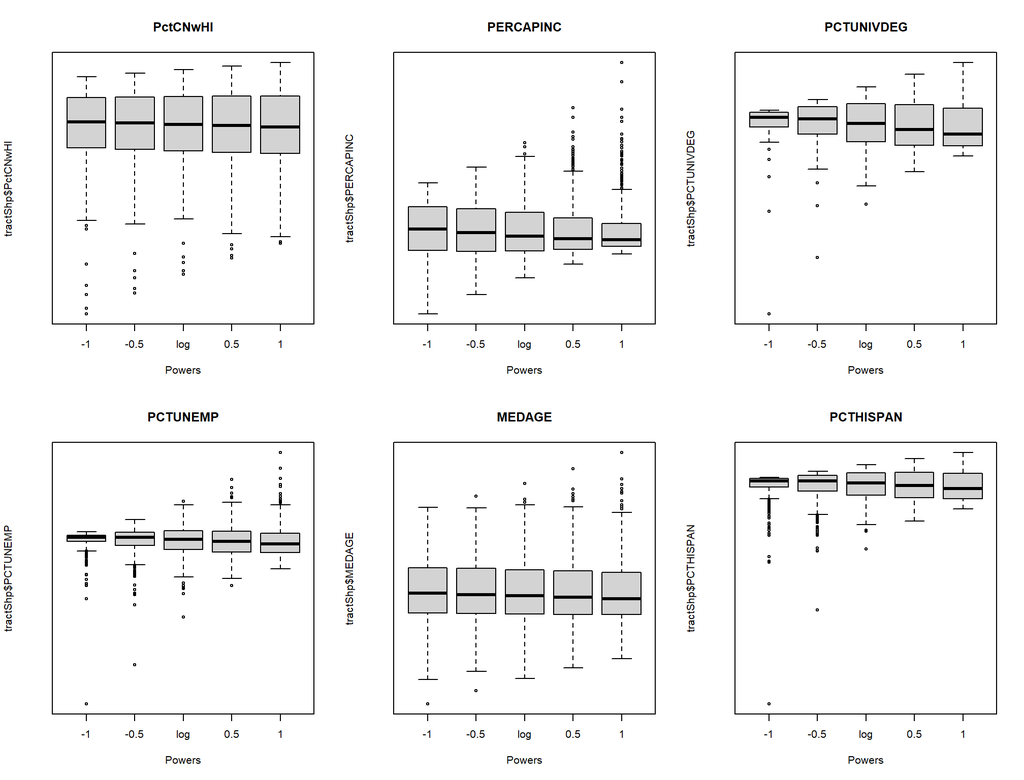

```r
##
## Visual Exploration and Transformation
##

## --- [Step 1] Symbox: check transformation necessity for each variable ---
layout(matrix(1:6, nrow = 2, ncol = 3, byrow = TRUE))          # 2x3 grid for 6 plots
symbox(tractShp$PctCNwHI,   main = "PctCNwHI")   # dependent variable
symbox(tractShp$PERCAPINC,  main = "PERCAPINC")
symbox(tractShp$PCTUNIVDEG, main = "PCTUNIVDEG")
symbox(tractShp$PCTUNEMP,   main = "PCTUNEMP")
symbox(tractShp$MEDAGE,     main = "MEDAGE")
symbox(tractShp$PCTHISPAN,  main = "PCTHISPAN")
```

```r
layout(1)                                         # reset layout
```

The `symbox()` function displays side-by-side boxplots of each variable under different Box-Cox power transformations (λ = -1, -0.5, 0, 0.5, 1), allowing visual comparison of symmetry across transformations. The most symmetric boxplot — indicated by equal whisker lengths and a centered median line — identifies the most appropriate transformation for each variable.

For the dependent variable `PctCNwHI`, the boxplot at λ = 1 already shows relatively balanced whiskers and a centered median. Therefore, no transformation is applied.

For `PERCAPINC`, the original distribution (λ = 1) shows a noticeably longer upper whisker with many high-value outliers, indicating right skewness. The log transformation (λ = 0) produces the most symmetric boxplot, so `log(PERCAPINC)` is applied.

For `PCTUNIVDEG`, the original distribution (λ = 1) is right-skewed with an extended upper whisker. The symbox plot suggests that λ = 0.5 (square root) achieves better symmetry; however, given that the log transformation allows regression coefficients to be interpreted as elasticities, `log(PCTUNIVDEG)` is preferred over the square root transformation.

For `MEDAGE`, the boxplots across all transformations look similar with no clear improvement from any transformation. The original distribution (λ = 1) is already reasonably symmetric, so no transformation is applied.

For `PCTHISPAN`, although the original distribution (λ = 1) shows some right skewness, the log transformation (λ = 0) over-corrects and produces a left-skewed distribution, which is worse than the original. Therefore, no transformation is applied to `PCTHISPAN`.

### Relationships Among Metric Variables

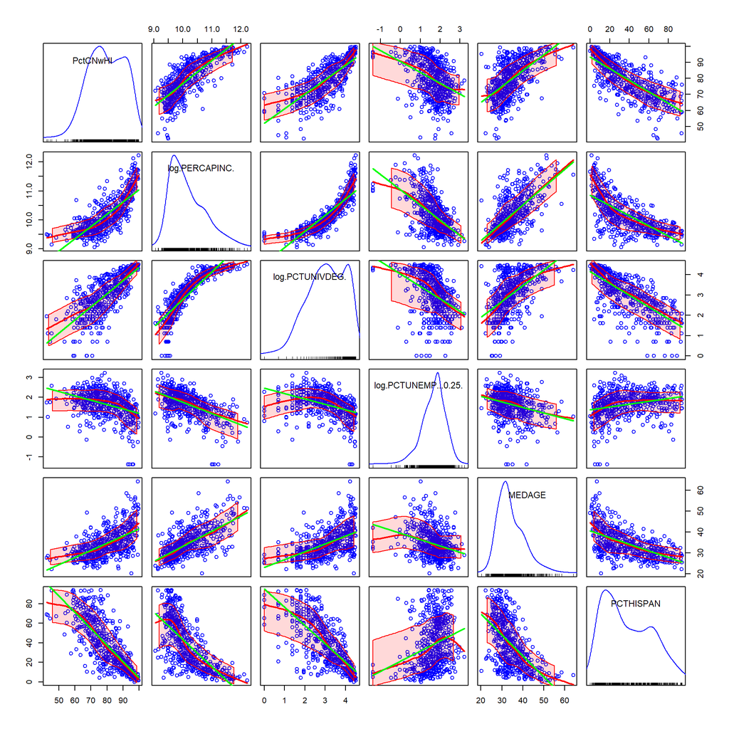

```r
## --- [Step 2] Scatterplot matrix (apply transformations per symbox results) ---
## PctCNwHI : no transformation (already symmetric)
## PERCAPINC : log transformation
## PCTUNIVDEG: log transformation
## PCTUNEMP  : log transformation with offset 0.25 (contains zero values)
## MEDAGE    : no transformation (already symmetric)
## PCTHISPAN : no transformation (log over-corrects to left skew)
scatterplotMatrix(~ PctCNwHI + log(PERCAPINC) + log(PCTUNIVDEG) +
                    log(PCTUNEMP + 0.25) + MEDAGE + PCTHISPAN,
                  data = tractShp@data, diagonal = "density",
                  smooth = list(span = 0.5, lty.smooth = 1,
                                col.smooth = "red", col.var = "red"),
                  regLine = list(col = "green"))
```

The `scatterplotMatrix()` function displays pairwise scatter plots of all selected variables after applying the transformations determined from the `symbox()` analysis. Each diagonal cell shows the kernel density estimate of the variable’s distribution. The green line represents the linear regression fit, while the red smoother captures any non-linear trend. Variables that required log transformation (`PERCAPINC`, `PCTUNIVDEG`, `PCTUNEMP`) are entered in their transformed form, with `PCTUNEMP` using an offset of 0.25 to handle zero values. `PctCNwHI`, `MEDAGE`, and `PCTHISPAN` are kept in their original scale.

#### Relationship between `PctCNwHI` and the metric independent variables:

The scatter plot matrix reveals that all selected metric independent variables show a meaningful relationship with the health insurance coverage rate (`PctCNwHI`), all consistent with the hypotheses formulated in Task [1].

`log(PERCAPINC)` shows a positive relationship with `PctCNwHI`. The red smoother curves slightly away from the green regression line, suggesting a mild non-linear pattern where the rate of increase in health insurance coverage slows down at higher income levels. `log(PCTUNIVDEG)` also shows a positive relationship, with the smoother indicating a slight non-linearity where coverage tends to rise more steeply at higher education levels. `log(PCTUNEMP + 0.25)` shows a negative relationship with `PctCNwHI`, with the smoother closely following the regression line, suggesting the relationship is approximately linear. `MEDAGE` shows a positive relationship with `PctCNwHI`, with the smoother curving slightly away from the regression line, indicating a mild non-linear trend. `PCTHISPAN` shows a negative relationship with `PctCNwHI`, with the smoother broadly following the regression line, though the scatter is relatively wide. All observed directions are consistent with the hypotheses formulated in Task [1]. The identified non-linearities will be formally tested in Task [3] using `car::residualPlots()`.

### Relationships Between Factor and Metric Variables

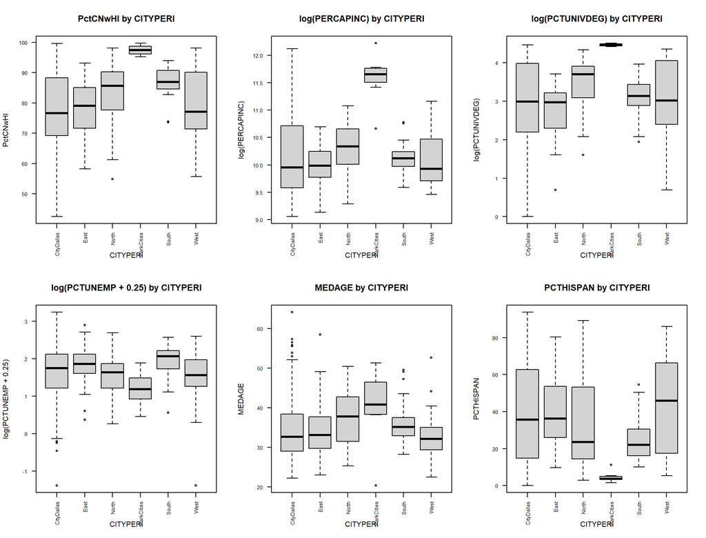

```r
## Effect of CITYPERI on metric independent variables (visual)
## Reference: Chapt03a.r - boxplot(water81~retire, data=concord)

opar <- par(mfrow=c(2,3))                          # 2x3 grid for 6 variables

boxplot(PctCNwHI ~ CITYPERI, data=tractShp@data,
        cex.axis=0.7, las=2,
        main="PctCNwHI by CITYPERI")

boxplot(log(PERCAPINC) ~ CITYPERI, data=tractShp@data,
        cex.axis=0.7, las=2,
        main="log(PERCAPINC) by CITYPERI")

boxplot(log(PCTUNIVDEG) ~ CITYPERI, data=tractShp@data,
        cex.axis=0.7, las=2,
        main="log(PCTUNIVDEG) by CITYPERI")

boxplot(log(PCTUNEMP + 0.25) ~ CITYPERI, data=tractShp@data,
        cex.axis=0.7, las=2,
        main="log(PCTUNEMP + 0.25) by CITYPERI")

boxplot(MEDAGE ~ CITYPERI, data=tractShp@data,
        cex.axis=0.7, las=2,
        main="MEDAGE by CITYPERI")

boxplot(PCTHISPAN ~ CITYPERI, data=tractShp@data,
        cex.axis=0.7, las=2,
        main="PCTHISPAN by CITYPERI")
```

```r
par(opar)                                          # reset layout
```

#### Relationship between `CITYPERI` and the metric independent variables:

The boxplots reveal that `ParkCities` stands out consistently across almost all metric variables. It shows by far the highest median `log(PERCAPINC)` (approximately 11.7), the highest median `log(PCTUNIVDEG)`, and the highest median `MEDAGE`, while simultaneously exhibiting the lowest `PCTHISPAN` and the lowest `log(PCTUNEMP + 0.25)`. This indicates that `ParkCities` is characterized by high income, high education, an older population, low unemployment, and a predominantly non-Hispanic composition — all at the same time. Among the remaining regions, `North` shows a slightly higher `log(PERCAPINC)` and `log(PCTUNIVDEG)` compared to other non-ParkCities areas. `CityDallas` and `West` exhibit the widest interquartile ranges across multiple variables, reflecting greater internal socioeconomic heterogeneity within these regions. These systematic differences between `CITYPERI` levels and the metric variables suggest potential overlap in the variation captured by the factor and the metric predictors, which may contribute to multicollinearity in the regression model. This will be formally assessed using `car::vif()` in Task [3].

## Preliminary Regression Model and Diagnostics (3 points)

Build a preliminary regression model and perform a proper model diagnostics:

- Signs and significance of the independent variables and $R^2$ with and without the factor variable.
- Partial $F$-test for the factors. Does the factor mask the importance of the metric independent variables or is insignificant and thus should be dropped?
- Multicollinearity investigation with `car::vif( )`.
- Non-linearity and quadratic term with `car::residualPlots( )`.
- Normality of the regression residuals with `car::qqPlot( )`.
- Influential cases investigation with `car::influenceIndexPlot( )`.
- Do extreme observations require special handling?

*Your answer goes here*

### Signs, Significance, and R² (with and without factor)

```r
## ---[Step 1] Build a full model including factors---
mod.full <- lm(PctCNwHI ~ log(PERCAPINC) + log(PCTUNIVDEG) +
                           log(PCTUNEMP + 0.25) + MEDAGE + PCTHISPAN + CITYPERI,
               data = tractShp@data)
summary(mod.full)
```

```
Call:
lm(formula = PctCNwHI ~ log(PERCAPINC) + log(PCTUNIVDEG) + log(PCTUNEMP +
    0.25) + MEDAGE + PCTHISPAN + CITYPERI, data = tractShp@data)

Residuals:
     Min       1Q   Median       3Q      Max
-23.4370  -3.1699   0.3983   3.4165  17.5218

Coefficients:
                     Estimate Std. Error t value Pr(>|t|)
(Intercept)           4.71859   10.06377   0.469 0.639362
log(PERCAPINC)        7.55833    1.13195   6.677 6.32e-11 ***
log(PCTUNIVDEG)       1.03234    0.61599   1.676 0.094362 .
log(PCTUNEMP + 0.25) -0.51764    0.48940  -1.058 0.290694
MEDAGE                0.03320    0.05502   0.603 0.546469
PCTHISPAN            -0.18332    0.01662 -11.031  < 2e-16 ***
CITYPERIEast          2.36921    0.77732   3.048 0.002423 **
CITYPERINorth         2.00326    0.93587   2.141 0.032781 *
CITYPERIParkCities    0.60070    2.23661   0.269 0.788363
CITYPERISouth         7.06069    1.11603   6.327 5.45e-10 ***
CITYPERIWest          2.85869    0.76099   3.757 0.000192 ***
---
Signif. codes:  0 '***' 0.001 '**' 0.01 '*' 0.05 '.' 0.1 ' ' 1

Residual standard error: 5.873 on 515 degrees of freedom
Multiple R-squared:  0.7452,    Adjusted R-squared:  0.7402
F-statistic: 150.6 on 10 and 515 DF,  p-value: < 2.2e-16
```

```r
## Model without factor (for partial F-test)
mod.metric <- lm(PctCNwHI ~ log(PERCAPINC) + log(PCTUNIVDEG) +
                              log(PCTUNEMP + 0.25) + MEDAGE + PCTHISPAN,
                 data = tractShp@data)
summary(mod.metric)
```

```
Call:
lm(formula = PctCNwHI ~ log(PERCAPINC) + log(PCTUNIVDEG) + log(PCTUNEMP +
    0.25) + MEDAGE + PCTHISPAN, data = tractShp@data)

Residuals:
     Min       1Q   Median       3Q      Max
-24.6947  -3.2542   0.5377   3.7448  18.8894

Coefficients:
                     Estimate Std. Error t value Pr(>|t|)
(Intercept)          19.11893    9.76146   1.959  0.05069 .
log(PERCAPINC)        5.99268    1.09088   5.493 6.18e-08 ***
log(PCTUNIVDEG)       1.68991    0.61081   2.767  0.00586 **
log(PCTUNEMP + 0.25) -0.45322    0.50218  -0.902  0.36721
MEDAGE                0.06775    0.05572   1.216  0.22459
PCTHISPAN            -0.19228    0.01696 -11.339  < 2e-16 ***
---
Signif. codes:  0 '***' 0.001 '**' 0.01 '*' 0.05 '.' 0.1 ' ' 1

Residual standard error: 6.127 on 520 degrees of freedom
Multiple R-squared:   0.72, Adjusted R-squared:  0.7173
F-statistic: 267.4 on 5 and 520 DF,  p-value: < 2.2e-16
```

The full model `mod.full` (including `CITYPERI`) achieves an Adjusted R² of 0.7402,explaining approximately 74% of the variation in `PctCNwHI` across the 526 census tracts. In comparison, the metric-only model `mod.metric` (excluding `CITYPERI`) achieves a lower Adjusted R² of 0.7173. The addition of the factor variable `CITYPERI` increases the Adjusted R² by approximately 2.3 percentage points, indicating that the geographic subdivision captures additional variation in health insurance coverage beyond what the metric variables alone can explain.

Regarding the signs of the coefficients, `log(PERCAPINC)` carries a positive coefficient (7.558, p < 0.001), consistent with the hypothesis that higher income tracts have greater insurance coverage. `PCTHISPAN` carries a negative coefficient (-0.183, p < 0.001), consistent with the hypothesis that a larger Hispanic population share is associated with lower coverage rates. These two variables are the only metric variables that remain statistically significant in `mod.full` after controlling for `CITYPERI`.

Notably, `log(PCTUNIVDEG)` is significant (p = 0.006) in the metric-only model `mod.metric` but becomes only marginally significant (p = 0.094) in `mod.full`, suggesting that `CITYPERI` partially absorbs the variation attributed to education. `log(PCTUNEMP + 0.25)` and `MEDAGE` are not significant in either model, which may indicate that their effects are already captured by other variables in the model or that their relationships with `PctCNwHI` are not linear after transformation.

Among the `CITYPERI` factor levels, `CITYPERISouth` (7.061, p < 0.001), `CITYPERIEast` (2.369, p = 0.002), `CITYPERIWest` (2.859, p < 0.001), and `CITYPERINorth` (2.003, p = 0.033) are all significantly higher than the baseline level `CityDallas`, suggesting that census tracts outside the core city of Dallas tend to have higher health insurance rates even after controlling for the metric variables. `CITYPERIParkCities` is not significant (p = 0.788), which may be because its characteristically high income and education levels are already fully captured by `log(PERCAPINC)` and `log(PCTUNIVDEG)`.

### Partial F-test for `CITYPERI`

```r
## --- [Step 2] Partial F-test for CITYPERI ---
anova(mod.metric, mod.full)   # H0: all CITYPERI levels = 0
```

```
Analysis of Variance Table

Model 1: PctCNwHI ~ log(PERCAPINC) + log(PCTUNIVDEG) + log(PCTUNEMP +
    0.25) + MEDAGE + PCTHISPAN
Model 2: PctCNwHI ~ log(PERCAPINC) + log(PCTUNIVDEG) + log(PCTUNEMP +
    0.25) + MEDAGE + PCTHISPAN + CITYPERI
  Res.Df   RSS Df Sum of Sq      F    Pr(>F)
1    520 19518
2    515 17762  5      1756 10.183 2.565e-09 ***
---
Signif. codes:  0 '***' 0.001 '**' 0.01 '*' 0.05 '.' 0.1 ' ' 1
```

The partial F-test comparing `mod.metric` and `mod.full` yields F(5, 515) = 10.183 with p = 2.565e-09 (***), strongly rejecting the null hypothesis that all five `CITYPERI` coefficient levels are simultaneously equal to zero. Therefore, `CITYPERI` as a whole contributes significantly to explaining the variation in `PctCNwHI` and should be retained in the model.

Furthermore, a comparison of the metric-only model `mod.metric` and the full model `mod.full` shows that `CITYPERI` does not appear to mask the importance of the metric variables — `log(PERCAPINC)` and `PCTHISPAN` remain strongly significant in both models. The main effect is that `CITYPERI` partially absorbs the contribution of `log(PCTUNIVDEG)`, reducing its significance from p = 0.006 to p = 0.094. This suggests a partial overlap between geographic location and education level, which was anticipated from the boxplot analysis in Task [2].

### Multicollinearity (`car::vif()`)

```r
## --- [Step 3] VIF for multicollinearity ---
car::vif(mod.full)
```

```
                         GVIF Df GVIF^(1/(2*Df))
log(PERCAPINC)       7.648521  1        2.765596
log(PCTUNIVDEG)      5.521421  1        2.349770
log(PCTUNEMP + 0.25) 1.553948  1        1.246575
MEDAGE               2.113854  1        1.453910
PCTHISPAN            2.594386  1        1.610710
CITYPERI             1.388443  5        1.033363
```

The variance inflation factors for `mod.full` indicate that `log(PERCAPINC)` (`GVIF^(1/(2*Df)) = 2.766`) and `log(PCTUNIVDEG)` (`GVIF^(1/(2*Df)) = 2.350`) show the highest inflation among the metric variables, which is consistent with the strong positive correlation between income and education observed in the scatterplot matrix in Task [2]. The remaining variables show `GVIF^(1/(2*Df))` values below 1.7, and the factor `CITYPERI` shows a `GVIF^(1/(2*Df))` of 1.033, indicating negligible inflation. Overall, multicollinearity appears to have only a modest impact on the estimates of `mod.full` — all regression coefficients carry the theoretically expected signs, and the statistically significant predictors remain significant. Therefore, multicollinearity does not pose a serious threat to the stability of the coefficient estimates in `mod.full`.

### Non-linearity (`car::residualPlots()`)

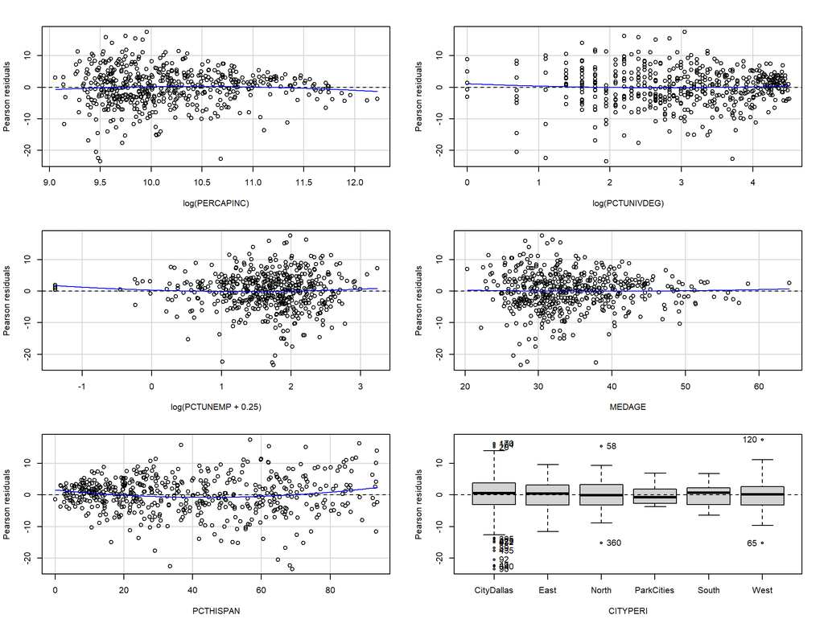

```
                     Test stat Pr(>|Test stat|)
log(PERCAPINC)         -1.1698         0.242632
log(PCTUNIVDEG)         1.2422         0.214725
log(PCTUNEMP + 0.25)    0.8662         0.386801
MEDAGE                  0.2814         0.778490
PCTHISPAN               3.2709         0.001144 **
CITYPERI
---
Signif. codes:  0 '***' 0.001 '**' 0.01 '*' 0.05 '.' 0.1 ' ' 1
```

```r
## --- [Step 4] Non-linearity check ---
car::residualPlots(mod.full, fitted=FALSE, layout=c(3,2))
```

The `residualPlots()` output tests for a significant Tukey quadratic term for each predictor. Among all variables, only `PCTHISPAN` shows a statistically significant non-linear pattern (Test stat = 3.271, p = 0.001). Inspecting the corresponding scatter plot of Pearson residuals against `PCTHISPAN` in Image 1, a slight upward curvature is visible at higher values of `PCTHISPAN`, confirming that the relationship between Hispanic population share and health insurance coverage is not fully captured by a linear term alone. Therefore, a quadratic term `I(PCTHISPAN^2)` will be added to the model to account for this non-linearity.

All other variables — `log(PERCAPINC)`, `log(PCTUNIVDEG)`, `log(PCTUNEMP + 0.25)`, and `MEDAGE` — show no significant non-linearity (all p > 0.05), and their residual plots show no systematic patterns. `CITYPERI` has no test statistic as it is a factor variable.

**Augmented Model with `I(PCTHISPAN^2)`**

```r
## --- [Step 4b] Augmented model with quadratic PCTHISPAN ---
mod.full2 <- lm(PctCNwHI ~ log(PERCAPINC) + log(PCTUNIVDEG) +
                             log(PCTUNEMP + 0.25) + MEDAGE +
                             PCTHISPAN + I(PCTHISPAN^2) + CITYPERI,
                data = tractShp@data)
summary(mod.full2)
```

```
Call:
lm(formula = PctCNwHI ~ log(PERCAPINC) + log(PCTUNIVDEG) + log(PCTUNEMP +
    0.25) + MEDAGE + PCTHISPAN + I(PCTHISPAN^2) + CITYPERI, data = tractShp@data)

Residuals:
     Min       1Q   Median       3Q      Max
-23.4047  -3.2538   0.2721   3.4557  18.1599

Coefficients:
                       Estimate Std. Error t value Pr(>|t|)
(Intercept)          17.5174724 10.7106867   1.636 0.102554
log(PERCAPINC)        6.3659581  1.1792011   5.399 1.03e-07 ***
log(PCTUNIVDEG)       1.5955179  0.6340899   2.516 0.012165 *
log(PCTUNEMP + 0.25) -0.4520360  0.4852751  -0.932 0.352030
MEDAGE                0.0281098  0.0545284   0.516 0.606420
PCTHISPAN            -0.3365367  0.0496521  -6.778 3.35e-11 ***
I(PCTHISPAN^2)        0.0016802  0.0005137   3.271 0.001144 **
CITYPERIEast          2.9432939  0.7898470   3.726 0.000216 ***
CITYPERINorth         1.8618244  0.9281914   2.006 0.045394 *
CITYPERIParkCities   -0.1082730  2.2264172  -0.049 0.961232
CITYPERISouth         7.2108062  1.1066215   6.516 1.72e-10 ***
CITYPERIWest          2.8863382  0.7539721   3.828 0.000145 ***
---
Signif. codes:  0 '***' 0.001 '**' 0.01 '*' 0.05 '.' 0.1 ' ' 1

Residual standard error: 5.818 on 514 degrees of freedom
Multiple R-squared:  0.7504,    Adjusted R-squared:  0.745
F-statistic: 140.5 on 11 and 514 DF,  p-value: < 2.2e-16
```

The augmented model `mod.full2` incorporates the quadratic term `I(PCTHISPAN^2)` identified as significant in the `residualPlots()` analysis. The results confirm that this addition is statistically justified and improves the model fit.

The quadratic term `I(PCTHISPAN^2)` is significant (coeff = 0.00168, p = 0.001), which is consistent with the visual evidence from the residual plot in Step 4. The combination of a negative linear coefficient for `PCTHISPAN` (-0.337) and a positive quadratic coefficient (0.00168) implies a concave-up (U-shaped) relationship: as the Hispanic population share increases from low to moderate levels, the health insurance rate decreases at a diminishing rate, and the decline slows down — or slightly reverses — at very high Hispanic concentration tracts. This pattern is substantively plausible: in neighborhoods where nearly the entire population is Hispanic, community-based outreach programs and Medicaid enrollment may partially offset the structural barriers to insurance coverage.

The Adjusted R² increases slightly from 0.7402 (`mod.full`) to 0.7450 (`mod.full2`), and the Residual Standard Error decreases from 5.873 to 5.818, indicating a modest but genuine improvement in model fit.

Notably, with the inclusion of `I(PCTHISPAN^2)`, the education variable `log(PCTUNIVDEG)` recovers full significance (p = 0.012), suggesting that its previous marginal significance in `mod.full` was partly a result of confounding with the non-linear Hispanic population effect. `log(PERCAPINC)` (p < 0.001) and `PCTHISPAN` (p < 0.001) remain the dominant metric predictors. `log(PCTUNEMP + 0.25)` and `MEDAGE` remain non-significant in the augmented model, which may suggest that their contributions are already captured by the combination of income, education, and geographic location. `CITYPERIParkCities` continues to be non-significant (p = 0.961), reinforcing the earlier interpretation that its distinctive socioeconomic profile is fully absorbed by the metric predictors. Therefore, `mod.full2` is adopted as the final OLS model and will serve as the basis for the heteroscedasticity investigation in Task [4].

### Normality of residuals (`car::qqPlot()`)

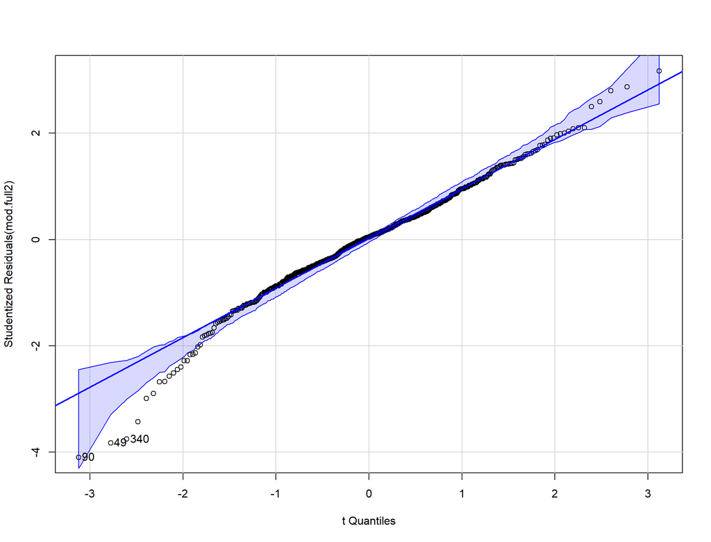

```
[1]  49  90 340
```

```r
## --- [Step 5] Normality of residuals ---
car::qqPlot(mod.full2, id=list(n=3, labels=rownames(tractShp@data)))
```

The Q-Q plot of the studentized residuals from the augmented model `mod.full2` shows that the central bulk of the residuals follows the theoretical t-distribution closely. The vast majority of observations align along the diagonal reference line and fall within the 95% confidence envelope, indicating that the normality assumption is broadly satisfied for the main body of the data.

### Influential cases (`car::influenceIndexPlot()`)

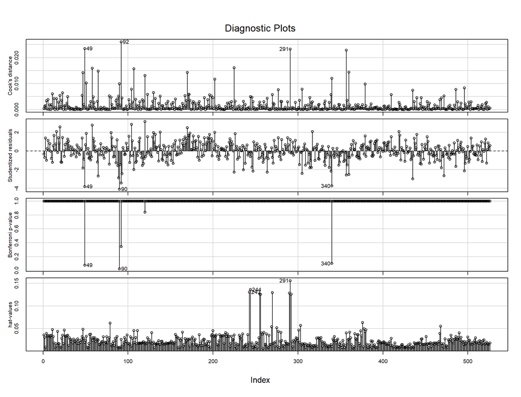

```r
## --- [Step 6] Influential cases for augmented model ---
car::influenceIndexPlot(mod.full2, id=list(n=3, labels=rownames(tractShp@data)))
```

### Handling extreme observations

The three census tracts flagged in the Q-Q plot and influence index plot — tracts 49 (`TRACT 48113009610`), 90 (`TRACT 48113007202`), and 340 (`TRACT 48113013621`) — are all located in `CityDallas` and show large negative studentized residuals, meaning their actual `PctCNwHI` values are substantially lower than what `mod.full2` predicts.

```r
## --- [Step 7] Inspect extreme tracts 49, 90, 340 ---
tractShp@data[c(49, 90, 340),
              c("TRACT", "CNPop", "PctCNwHI",
                "PERCAPINC", "PCTUNIVDEG",
                "PCTUNEMP", "MEDAGE",
                "PCTHISPAN", "CITYPERI")]
```

```
          TRACT CNPop PctCNwHI PERCAPINC PCTUNIVDEG PCTUNEMP MEDAGE PCTHISPAN
49  48113009610  4956 43.05892     13089          3 2.499094   28.5  68.25529
90  48113007202  8285 42.45021     13334          7 5.502670   27.6  68.95343
340 48113013621  4015 60.87173     43573         41 5.386251   37.8  33.46117
      CITYPERI
49  CityDallas
90  CityDallas
340 CityDallas
```

Tracts 49 and 90 share a similar data constellation: extremely low per capita income (~$13,000), very low university degree attainment (3% and 7% respectively), young median age (28–29 years), and a very high Hispanic population share (~68–69%). Although the model already accounts for the negative effect of a large Hispanic population share through the `PCTHISPAN` and `I(PCTHISPAN^2)` terms, the actual insurance rates of 43.1% and 42.5% are still far below the model’s predictions. This suggests that in highly concentrated Hispanic inner-city tracts, additional structural barriers — such as immigration status restrictions on Medicaid eligibility, language barriers in enrollment, and high rates of informal employment without employer-sponsored insurance — suppress coverage rates beyond what the selected predictors can capture.

Tract 340, by contrast, represents a distinctly different data constellation: relatively high per capita income ($43,573), substantial university degree attainment (41%), and a moderate Hispanic share (33.5%). The model predicts a high insurance rate based on its favorable socioeconomic profile, yet the actual `PctCNwHI` of only 60.9% is considerably lower. This may reflect a tract where a segment of higher-earning Hispanic residents — possibly self-employed individuals or undocumented immigrants not eligible for employer-sponsored or public insurance — depresses the coverage rate despite the otherwise favorable income and education levels.

To formally evaluate whether any of these three tracts qualifies as a statistically significant outlier, `car::outlierTest()` is applied. This function identifies the observation with the largest absolute studentized residual and reports a Bonferroni-adjusted p-value that accounts for simultaneously testing all 526 tracts.

```r
## --- [Step 8] Formal outlier test with Bonferroni correction ---
car::outlierTest(mod.full2, n.max = 5)
```

```
    rstudent unadjusted p-value Bonferroni p
90 -4.098857         4.8258e-05     0.025384
```

Following the outlier treatment logic demonstrated in `VacModelTX_trans.rmd`, tract 90 is removed from the dataset, and the augmented model `mod.full2` is refitted on the remaining **525 census tracts**. The `outlierTest()` is then re-applied to verify that no additional tracts become Bonferroni-significant once the most extreme observation has been removed.

```r
## --- [Step 9] Remove Bonferroni-significant outlier tract 90 ---
## Reason: studentized residual = -4.099, Bonferroni p = 0.025 (< 0.05)
tractShp <- tractShp[-90, ]

## Update row-names after removal
rownames(tractShp@data) <- 1:nrow(tractShp@data)

## Refit the augmented model on the 525 remaining tracts
mod.full2 <- lm(PctCNwHI ~ log(PERCAPINC) + log(PCTUNIVDEG) +
                             log(PCTUNEMP + 0.25) + MEDAGE +
                             PCTHISPAN + I(PCTHISPAN^2) + CITYPERI,
                data = tractShp@data)
summary(mod.full2)
```

```
Call:
lm(formula = PctCNwHI ~ log(PERCAPINC) + log(PCTUNIVDEG) + log(PCTUNEMP +
    0.25) + MEDAGE + PCTHISPAN + I(PCTHISPAN^2) + CITYPERI, data = tractShp@data)

Residuals:
     Min       1Q   Median       3Q      Max
-21.9482  -3.2559   0.2896   3.3958  18.1431

Coefficients:
                      Estimate Std. Error t value Pr(>|t|)
(Intercept)          18.379247  10.551856   1.742 0.082142 .
log(PERCAPINC)        6.291630   1.161625   5.416 9.37e-08 ***
log(PCTUNIVDEG)       1.606031   0.624568   2.571 0.010409 *
log(PCTUNEMP + 0.25) -0.489934   0.478073  -1.025 0.305936
MEDAGE                0.026711   0.053710   0.497 0.619173
PCTHISPAN            -0.334852   0.048908  -6.847 2.17e-11 ***
I(PCTHISPAN^2)        0.001677   0.000506   3.314 0.000985 ***
CITYPERIEast          2.849661   0.778315   3.661 0.000277 ***
CITYPERINorth         1.788843   0.914419   1.956 0.050977 .
CITYPERIParkCities   -0.061698   2.192995  -0.028 0.977566
CITYPERISouth         7.151633   1.090090   6.561 1.31e-10 ***
CITYPERIWest          2.782995   0.743072   3.745 0.000201 ***
---
Signif. codes:  0 '***' 0.001 '**' 0.01 '*' 0.05 '.' 0.1 ' ' 1

Residual standard error: 5.731 on 513 degrees of freedom
Multiple R-squared:  0.7534,    Adjusted R-squared:  0.7482
F-statistic: 142.5 on 11 and 513 DF,  p-value: < 2.2e-16
```

```r
## Re-check for any remaining Bonferroni-significant outliers
car::outlierTest(mod.full2, n.max = 5)
```

```
No Studentized residuals with Bonferroni p < 0.05
Largest |rstudent|:
    rstudent unadjusted p-value Bonferroni p
49 -3.921395         0.00010003     0.052514
```

After removing tract 90, the refitted `mod.full2` shows **no remaining Bonferroni-significant outliers** (`outlierTest()` reports “No Studentized residuals with Bonferroni p < 0.05”). The sequential outlier treatment is therefore concluded after a single removal.

The model fit improves modestly: Adjusted R² rises from 0.7450 to 0.7482, and the residual standard error decreases from 5.818 to 5.731. This is consistent with the expectation that tract 90 was an isolated extreme observation rather than a symptom of deeper model misspecification. The final OLS model based on **525 census tracts** will serve as the basis for the heteroscedasticity investigation in Task [4] and the spatial autocorrelation analysis in Task [5].

## Revised Final Regression Model Specification (1.5 points)

Based on what you have learnt in the previous task *adjust* your regression model and properly interpret your final model in the light of the formulated direction of influence in the section on the selection of independent variables:

- Signs and significance of the regression coefficients $\beta$ and $R^2$,
  - perhaps as elasticity and with
  - conditional effects plots to visualize any non-linearities with `effects::allEffects( )`.

*Your answer goes here*

### Model Adjustment: Dropping Non-significant Variables

```r
## --- [Step 1] Drop non-significant metric variables ---
mod.final <- update(mod.full2, . ~ . - log(PCTUNEMP + 0.25) - MEDAGE)
summary(mod.final)
```

```
Call:
lm(formula = PctCNwHI ~ log(PERCAPINC) + log(PCTUNIVDEG) + PCTHISPAN +
    I(PCTHISPAN^2) + CITYPERI, data = tractShp@data)

Residuals:
    Min      1Q  Median      3Q     Max
-21.674  -3.244   0.279   3.498  18.004

Coefficients:
                    Estimate Std. Error t value Pr(>|t|)
(Intercept)        12.229159   8.911618   1.372 0.170576
log(PERCAPINC)      6.953502   0.952822   7.298 1.11e-12 ***
log(PCTUNIVDEG)     1.462455   0.601832   2.430 0.015439 *
PCTHISPAN          -0.337691   0.048565  -6.953 1.09e-11 ***
I(PCTHISPAN^2)      0.001703   0.000505   3.372 0.000803 ***
CITYPERIEast        2.860558   0.776005   3.686 0.000252 ***
CITYPERINorth       1.917192   0.899076   2.132 0.033446 *
CITYPERIParkCities -0.435585   2.157501  -0.202 0.840080
CITYPERISouth       7.123980   1.082348   6.582 1.15e-10 ***
CITYPERIWest        2.837993   0.739849   3.836 0.000141 ***
---
Signif. codes:  0 '***' 0.001 '**' 0.01 '*' 0.05 '.' 0.1 ' ' 1

Residual standard error: 5.726 on 515 degrees of freedom
Multiple R-squared:  0.7529,    Adjusted R-squared:  0.7485
F-statistic: 174.3 on 9 and 515 DF,  p-value: < 2.2e-16
```

```r
## --- [Step 2] Partial F-test: verify drop is justified ---
## H0: beta_PCTUNEMP = beta_MEDAGE = 0
anova(mod.final, mod.full2)
```

```
Analysis of Variance Table

Model 1: PctCNwHI ~ log(PERCAPINC) + log(PCTUNIVDEG) + PCTHISPAN + I(PCTHISPAN^2) +
    CITYPERI
Model 2: PctCNwHI ~ log(PERCAPINC) + log(PCTUNIVDEG) + log(PCTUNEMP +
    0.25) + MEDAGE + PCTHISPAN + I(PCTHISPAN^2) + CITYPERI
  Res.Df   RSS Df Sum of Sq      F Pr(>F)
1    515 16887
2    513 16848  2    39.232 0.5973 0.5507
```

In the previous task, the augmented model `mod.full2` revealed that `log(PCTUNEMP + 0.25)` (p = 0.306) and `MEDAGE` (p = 0.619) are both statistically insignificant. Following the parsimony principle and the model adjustment pattern demonstrated in `ConcordH2O.R`, these two variables are dropped, and a partial F-test is applied to formally verify that their joint contribution to the model is negligible.

The partial F-test yields F(2, 513) = 0.597 with p = 0.551, which strongly accepts the null hypothesis that both dropped variables jointly have zero effect on `PctCNwHI`. This confirms that the reduced model `mod.final` is the preferred specification. Furthermore, the Adjusted R² actually rises slightly from 0.7482 in `mod.full2` to 0.7485 in `mod.final`, and the residual standard error drops marginally from 5.731 to 5.726 — both consistent with the principle of parsimony that penalizes retaining uninformative predictors.

#### Interpretation of the Final OLS Model

**Signs, significance, and R²**

All retained regression coefficients in `mod.final` carry the expected signs formulated in Task [1], and all metric predictors are statistically significant:

- `log(PERCAPINC)` = 6.954 (p < 0.001), per capita income is the dominant economic driver of health insurance coverage. Since the dependent variable `PctCNwHI` is in its original percentage scale while the regressor is log-transformed, the coefficient has a level-log (semi-elasticity) interpretation: a 1% increase in PERCAPINC is associated with an increase in `PctCNwHI` of approximately 6.954/100 ≈ 0.070 percentage points. Equivalently, a 10% increase in income raises the expected coverage rate by roughly 0.66 percentage points, and doubling a tract’s per capita income raises the expected rate by approximately 4.82 percentage points.
- `log(PCTUNIVDEG)` = 1.462 (p = 0.015), the share of college-educated residents also has a positive and significant effect, consistent with the hypothesis that higher educational attainment leads to greater awareness of and access to health insurance. A 10% increase in `PCTUNIVDEG` is associated with approximately 0.14 percentage points increase in `PctCNwHI` — notably smaller in magnitude than the income effect.
- `PCTHISPAN` = -0.338 (p < 0.001) combined with `I(PCTHISPAN^2)` = 0.00170 (p < 0.001) describes a concave-up (U-shaped) relationship. The turning point lies at 0.338 / (2 × 0.00170) ≈ 99.3%, which falls outside the effective range of the data (max observed ≈ 94%). Consequently, `PctCNwHI` decreases monotonically across the observed range of `PCTHISPAN`, but the rate of decline slows down as the Hispanic share approaches very high levels.
- The factor `CITYPERI` continues to contribute significantly to the model. Compared to the baseline level `CityDallas`, census tracts in `South` (+7.124, p < 0.001), `East` (+2.861, p < 0.001), `West` (+2.838, p < 0.001), and `North` (+1.917, p = 0.033) all show higher expected `PctCNwHI`. `ParkCities` is essentially indistinguishable from `CityDallas` (-0.436, p = 0.840), which makes sense because its distinctive socioeconomic profile (very high income, high education, older population) is already fully absorbed by `log(PERCAPINC)` and `log(PCTUNIVDEG)` in the model. Despite this non-significant single level, the factor as a whole was shown to be highly significant in the partial F-test of Task [3], and is therefore retained in its entirety following the rule that a factor must be either kept or dropped as a unit.

### Conditional Effects Plots Interpretation

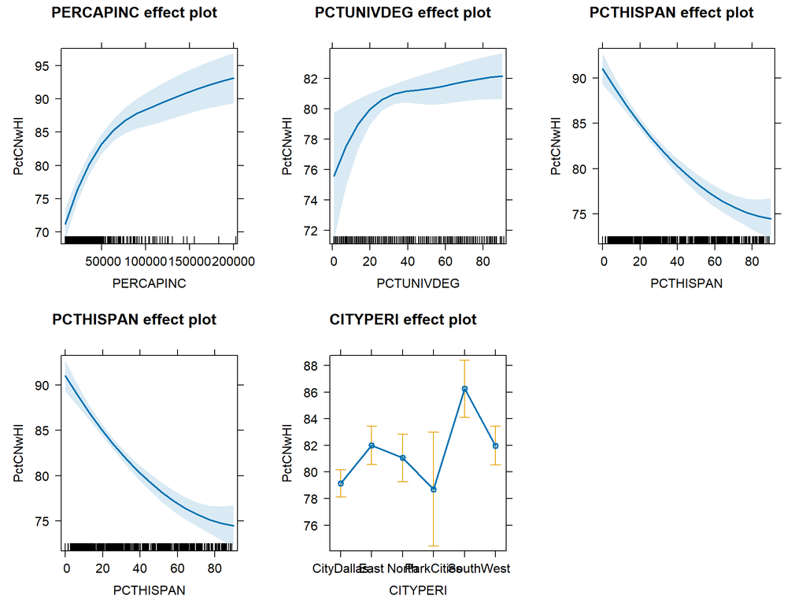

```r
## --- [Step 3] Conditional effects plots ---
effFinal <- effects::allEffects(mod.final)
plot(effFinal)
```

The `effects::allEffects()` conditional effects plots visualize the partial relationship between `PctCNwHI` and each predictor, with all other variables held at their sample means. This restores the original, un-transformed scale of each variable, which makes the non-linearities introduced by the log transformations and the quadratic term much easier to interpret intuitively.

- **PERCAPINC**: the fitted curve rises in a **concave-down** fashion from approximately 70% at $15,000 per capita income to approximately 93% at $200,000 — steep at low income levels and gradually flattening at higher incomes. This diminishing-returns pattern is the characteristic shape of a log-linear (semi-elasticity) relationship, and confirms that per capita income is the dominant economic driver of health insurance coverage.
- **PCTUNIVDEG**: a similar **concave-down** (diminishing returns) curve, rising steeply at low education levels and gradually flattening at higher values, but with a noticeably gentler overall slope (approximately a 7 percentage point increase across the full range of education), consistent with the smaller regression coefficient of 1.46 compared to 6.95 for income.
- **PCTHISPAN**: the plot appears twice because `allEffects()` treats `PCTHISPAN` and `I(PCTHISPAN^2)` as two separate predictor terms; both plots display the same combined linear + quadratic effect. The curve shows a clear downward trend from approximately 91% at 0% Hispanic share to approximately 74% at 90% Hispanic share, with a slight concave-up flattening at very high concentrations — visually confirming the U-shaped relationship implied by the quadratic coefficient.
- **CITYPERI**: `South` stands out with the highest predicted rate of approximately 86%, `East`, `North`, and `West` cluster around 81–82%, and `CityDallas` and `ParkCities` sit at the bottom with nearly identical predicted rates of approximately 79%. This pattern directly visualizes why the `CITYPERIParkCities` coefficient is not significant — after controlling for income and education, Park Cities and CityDallas are indistinguishable. The wider confidence interval around `ParkCities` also reflects its small sample size (only 8 tracts in the dataset).

All observed patterns in the conditional effects plots are consistent with the hypotheses formulated in Task [1]. `mod.final` is therefore adopted as the final OLS specification and will serve as the baseline for the heteroscedasticity investigation in Task [5].

## Heteroscedasticity Investigation (1.5 points)

- Justify your selection of the *weights variable*.
- Estimate the model $\sigma_i^2=exp(\gamma_0\cdot1+\gamma_1\cdot\log{(weightVar_i)})$ with `TexMix::lmHetero( )`.
- Interpret of gamma parameter $\gamma_1$ associated with your weights variable and the likelihood ratio test.
- Does the interpretation of the regression coefficients $\beta$ change substantially?
- If necessary, transcribe the model into a weighted regression model with `lm(..., weights=...)`.

*Your answer goes here*

### Selection of the Weights Variable

The dependent variable `PctCNwHI` is a rate constructed as `CNwHI / CNPop × 100`, where `CNPop` (civilian non-institutionalized population) serves as the population at risk in the denominator. Census tracts with a smaller `CNPop` are expected to produce less precise rate estimates, because in those tracts the observed `PctCNwHI` is more sensitive to small shifts in the numerator. This is exactly the pattern documented in `VacModelTX_trans.rmd` for `POP16PLUS` and in `MultiWeightedMaxLike.r` for the bladder cancer rate, where the denominator of the rate is used as the weights variable. Therefore, `log(CNPop)` is selected as the weights variable for the heteroscedastic ML-regression model.

```r
## --- [Step 1] Breusch-Pagan test for heteroscedasticity ---
car::ncvTest(mod.final, var.formula = ~ log(CNPop), data = tractShp@data)
```

```
Non-constant Variance Score Test
Variance formula: ~ log(CNPop)
Chisquare = 3.267239, Df = 1, p = 0.070676
```

A preliminary Breusch-Pagan test via `car::ncvTest()` is used to verify whether heteroscedasticity is systematically associated with `log(CNPop)` before fitting the weighted model. The test yields a Chi-square statistic of 3.267 with p = 0.071, which fails to reject the null hypothesis of homoscedasticity at the conventional α = 0.05 level. This is an early indication that heteroscedasticity with respect to `CNPop` is only marginal in this dataset.

### Heteroscedastic ML-Regression with `TexMix::lmHetero()`

```r
## --- [Step 2] Estimate heteroscedastic ML-regression model ---
## Note: the weights variable in lmHetero() must be log-transformed
mod.het <- TexMix::lmHetero(
    PctCNwHI ~ log(PERCAPINC) + log(PCTUNIVDEG) +
               PCTHISPAN + I(PCTHISPAN^2) + CITYPERI | log(CNPop),
    data = tractShp@data
)
summary(mod.het)
```

```
================================================================
Multiplicatively Weighted Heteroscedasticity ML-Regression Model
================================================================

Call:
TexMix::lmHetero(formula = PctCNwHI ~ log(PERCAPINC) + log(PCTUNIVDEG) +
    PCTHISPAN + I(PCTHISPAN^2) + CITYPERI | log(CNPop), data = tractShp@data)

Regression Coefficients:
                      Estimate     Std.Err z-value  Pr(>|z|)
(Intercept)        11.67567367  8.91395143  1.3098 0.1902567
log(PERCAPINC)      7.02762581  0.95258007  7.3775 1.614e-13 ***
log(PCTUNIVDEG)     1.40763688  0.59636078  2.3604 0.0182563 *
PCTHISPAN          -0.33917880  0.04819456 -7.0377 1.954e-12 ***
I(PCTHISPAN^2)      0.00172241  0.00050058  3.4408 0.0005799 ***
CITYPERIEast        2.93253725  0.75451992  3.8866 0.0001016 ***
CITYPERINorth       1.87568263  0.88757799  2.1133 0.0345786 *
CITYPERIParkCities -0.32858268  2.15161743 -0.1527 0.8786236
CITYPERISouth       7.16131958  1.05474786  6.7896 1.124e-11 ***
CITYPERIWest        2.84332051  0.73092612  3.8900 0.0001002 ***
---
Signif. codes:  0 '***' 0.001 '**' 0.01 '*' 0.05 '.' 0.1 ' ' 1

Gamma Coefficients:
               Gamma  Std.Err z-value  Pr(>|z|)
(Intercept)  4.94008  1.07357  4.6016 4.194e-06 ***
log(CNPop)  -0.17574  0.12781 -1.3751    0.1691
---
Signif. codes:  0 '***' 0.001 '**' 0.01 '*' 0.05 '.' 0.1 ' ' 1

log-likelihood = -1654.839

Heteroscedasticity likelihood ratio test:
       LR   df  Pr(Chi > LR)
 2.444385    1     0.1179461
```

The variance structure is modelled as

$$\sigma_i^2 = \exp(\gamma_0 \cdot 1 + \gamma_1 \cdot \log(CNPop_i))$$

and estimated by maximum likelihood with `TexMix::lmHetero()`. Following the requirement of the function, the weights variable is entered in its logarithmic form.

**Interpretation of `γ₁` and the likelihood ratio test**

The estimated gamma coefficient on `log(CNPop)` is `γ₁ = -0.176` with a standard error of 0.128 and a p-value of 0.169. The negative sign is consistent with statistical theory: as the civilian non-institutionalized population in a tract increases, the error variance of the observed `PctCNwHI` tends to decrease. However, the z-value of -1.375 is not statistically significant at α = 0.05, meaning that although the expected directional pattern is present, it cannot be clearly distinguished from random sampling variation.

### Does the Interpretation of the Regression Coefficients Change?

```r
## --- [Step 3] Transcribe to weighted lm model ---
mod.wlm <- lm(PctCNwHI ~ log(PERCAPINC) + log(PCTUNIVDEG) +
                         PCTHISPAN + I(PCTHISPAN^2) + CITYPERI,
              data = tractShp@data,
              weights = mod.het$weights)
summary(mod.wlm)
```

```
Call:
lm(formula = PctCNwHI ~ log(PERCAPINC) + log(PCTUNIVDEG) + PCTHISPAN +
    I(PCTHISPAN^2) + CITYPERI, data = tractShp@data, weights = mod.het$weights)

Weighted Residuals:
    Min      1Q  Median      3Q     Max
-3.8685 -0.5804  0.0427  0.5950  3.1127

Coefficients:
                     Estimate Std. Error t value Pr(>|t|)
(Intercept)        11.6759823  9.0000255   1.297 0.195099
log(PERCAPINC)      7.0275838  0.9617785   7.307 1.05e-12 ***
log(PCTUNIVDEG)     1.4076692  0.6021225   2.338 0.019777 *
PCTHISPAN          -0.3391781  0.0486602  -6.970 9.72e-12 ***
I(PCTHISPAN^2)      0.0017224  0.0005054   3.408 0.000706 ***
CITYPERIEast        2.9324993  0.7618179   3.849 0.000133 ***
CITYPERINorth       1.8757134  0.8961550   2.093 0.036832 *
CITYPERIParkCities -0.3286446  2.1723966  -0.151 0.879812
CITYPERISouth       7.1613014  1.0649481   6.725 4.69e-11 ***
CITYPERIWest        2.8433169  0.7379890   3.853 0.000132 ***
---
Signif. codes:  0 '***' 0.001 '**' 0.01 '*' 0.05 '.' 0.1 ' ' 1

Residual standard error: 1.01 on 515 degrees of freedom
Multiple R-squared:  0.7517,    Adjusted R-squared:  0.7473
F-statistic: 173.2 on 9 and 515 DF,  p-value: < 2.2e-16
```

Although no weighted adjustment is ultimately required, the weighted model `mod.wlm` is transcribed from `mod.het` and compared to the OLS model `mod.final` from Task [4] for verification purposes. The two sets of regression coefficients are nearly identical across all predictors — for example, `log(PERCAPINC)` changes from 6.954 to 7.028, `PCTHISPAN` remains essentially unchanged at -0.339, and the quadratic term `I(PCTHISPAN^2)` is stable at 0.00172. The standard errors are also essentially unchanged. This numerical equivalence is the expected outcome when `γ₁` is small and not significantly different from zero: with nearly uniform weights across observations, the weighted model collapses back to OLS. The interpretation of the regression coefficients given in Task [4] therefore remains fully valid and does not change substantially.

### Conclusion: No Heteroscedasticity Adjustment Needed

```r
## --- [Step 4] Confirm heteroscedasticity is removed in the weighted model ---
car::ncvTest(mod.wlm, var.formula = ~ log(CNPop), data = tractShp@data)
```

```
Non-constant Variance Score Test
Variance formula: ~ log(CNPop)
Chisquare = 4.03096e-08, Df = 1, p = 0.99984
```

Given the non-significant likelihood ratio test (p = 0.118), the marginal Breusch-Pagan result (p = 0.071), and the numerically indistinguishable coefficient estimates between `mod.final` and `mod.wlm`, no heteroscedasticity adjustment is warranted for this dataset. The final OLS model `mod.final` is retained as the baseline specification, and the unweighted regression residuals `residuals(mod.final)` will be used directly for the spatial autocorrelation analysis in Task [6] and, if indicated, for the SAR model estimation in Task [7].

As a final sanity check, `car::ncvTest(mod.wlm, var.formula = ~ log(CNPop))` is applied to the weighted model and returns a Chi-square statistic of essentially zero with p = 1.000. This confirms that the ML optimization in `lmHetero()` converged correctly and that any residual variance structure associated with `log(CNPop)` has been fully absorbed into the weighting scheme. It does not, however, constitute independent evidence of heteroscedasticity in the original model — that question was already answered by the likelihood ratio test above.

## Spatial Autocorrelation in the Regression Residuals (2 points)

- Map the residuals, and if necessary weighted residuals, with proper numbers of positive and negative classes.
- Interpret the map pattern for spatial clustering and spatial outliers.
- Map the spatial connectivity graph. Check for possible problems.
- Test for spatial autocorrelation wit Moran’s $I$.
- Generate a correlogram. Does its decay towards zero satisfy the criteria for a simultaneous autoregressive process (SAR)?

*Your answer goes here*

### Distribution of the OLS Regression Residuals

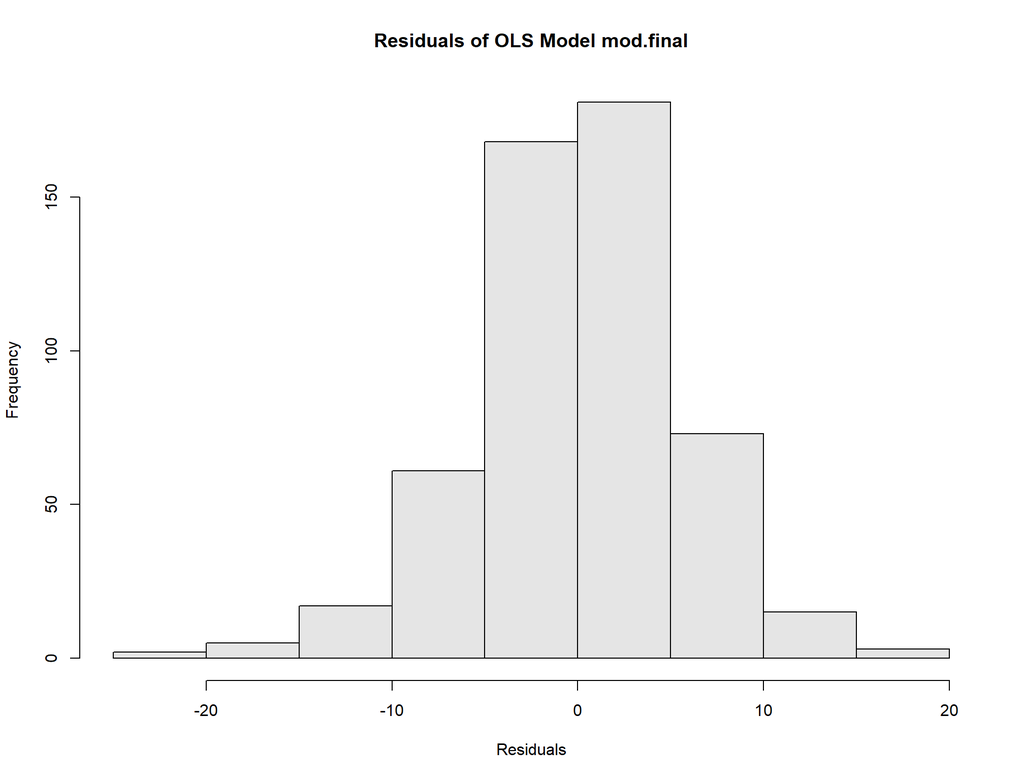

```r
## --- [Step 1] Spatial helper objects ---
tract.centroid <- coordinates(tractShp)   # tract centroids for link plotting
tract.bbox     <- bbox(tractShp)          # bounding box for map region

## --- [Step 2] OLS residuals (unweighted, per Task 5 conclusion) ---
modResid <- residuals(mod.final)

## Explore distribution to identify number of pos/neg classes
hist(modResid, main = "Residuals of OLS Model mod.final",
     xlab = "Residuals", col = "grey90")
```

```r
length(modResid[modResid <  0])           # number of tracts with negative residuals
```

```
[1] 253
```

```r
length(modResid[modResid >= 0])           # number of tracts with positive residuals
```

```
[1] 272
```

The histogram of the OLS residuals from `mod.final` shows a roughly symmetric distribution centered near zero, with the vast majority of residuals falling within ±10 percentage points. Out of the 525 census tracts, 272 tracts have positive residuals (where the actual `PctCNwHI` exceeds the model prediction) and 253 tracts have negative residuals. The split is nearly balanced with only a 19-tract difference between the two branches. Therefore, setting `neg.breaks = 5` and `pos.breaks = 5` in `mapBiPolar()` follows the convention in `SpatialACItaly.rmd` and produces classes with approximately equal tract counts in each category, making the bipolar color scale visually comparable across both signs.

### Spatial Pattern of the OLS Regression Residuals

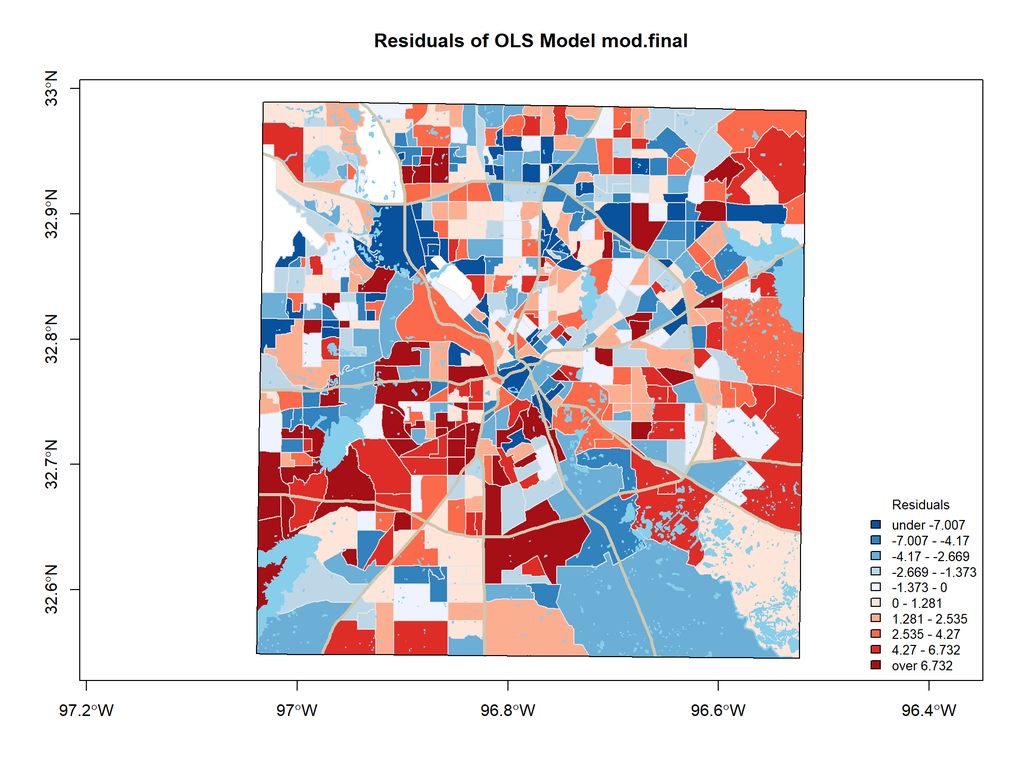

```r
## --- [Step 3] Bipolar residual map ---
mapBiPolar(modResid, tractShp,
           neg.breaks = 5, pos.breaks = 5, break.value = 0.0,
           map.title    = "Residuals of OLS Model mod.final",
           legend.title = "Residuals",
           legend.pos   = "bottomright",
           legend.cex   = 0.8)
plot(lakesShp, col="skyblue", border="skyblue", add=TRUE)
plot(hwyShp,   col="cornsilk3", lwd=3, add=TRUE)
plot(bndShp,   border="black", add=TRUE)
box()
```

The bipolar residual map reveals clear evidence of **positive spatial autocorrelation** — residuals of the same sign are not randomly scattered across Dallas County, but rather form distinct geographic clusters.

A large contiguous cluster of **strongly positive residuals (dark red)** is observed in the **southwestern sector** of the county. In these tracts, `mod.final` **under-predicts** `PctCNwHI` — the observed insurance coverage is higher than what the model implies.

Conversely, a cluster of **strongly negative residuals (blue)** is concentrated around the **inner urban core of Dallas**, with additional scattered blue patches in the northeastern sector. In these tracts, `mod.final` **over-predicts** `PctCNwHI` — the observed coverage is lower than the model implies.

Several **spatial outliers** — isolated red tracts embedded in blue neighborhoods, or vice versa — are also visible along the northern and eastern edges of the county. These will be diagnosed more rigorously in the Moran scatterplot below.

Overall, the strong spatial clustering visible in the map pattern suggests that **the spatial independence assumption of OLS is violated**, and spatial dependence should be explicitly modeled in Task [7].

### Spatial Connectivity Graph Diagnostics

```r
## --- [Step 4] Spatial connectivity graph ---
tract.link <- poly2nb(tractShp, queen = FALSE)     # rook contiguity
print(tract.link)                                   # diagnostic: n, nn, avg links
```

```
Neighbour list object:
Number of regions: 525
Number of nonzero links: 2710
Percentage nonzero weights: 0.98322
Average number of links: 5.161905
```

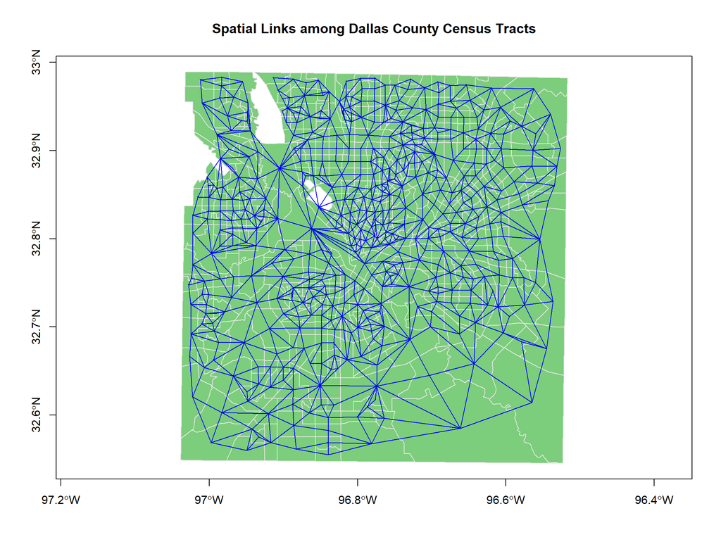

```r
## Plot spatial links focused at tract centroids
plot(tractShp, col = "palegreen3", border = grey(0.9), axes = TRUE,
     xlim = tract.bbox[1,], ylim = tract.bbox[2,])
plot(tract.link, coords = tract.centroid, pch = 19, cex = 0.1,
     col = "blue", add = TRUE)
title("Spatial Links among Dallas County Census Tracts")
box()
```

The rook-contiguity neighbors list produced by `poly2nb(tractShp, queen = FALSE)` reports 525 regions, 2,710 nonzero links, and an average of 5.16 links per tract — a typical value for census tracts in U.S. metropolitan counties. No warning message about disconnected regions is returned, confirming that every tract has at least one neighbor.

The visual connectivity graph also confirms that the link structure is complete and well-formed. The connectivity across the northwestern sector — where Lewisville Lake creates an irregular boundary — is successfully maintained through shared edges along the lakeshore, and no tracts appear as isolated islands. Furthermore, the removal of tract in Task [2] and the outlier tract sequence updated in Task [3]) did not produce any broken connectivity. Therefore, the spatial link matrix `tract.linkW` can be used directly for the Moran’s $I$ test and the subsequent SAR model without any manual augmentation.

### Moran’s $I$ Test for Spatial Autocorrelation

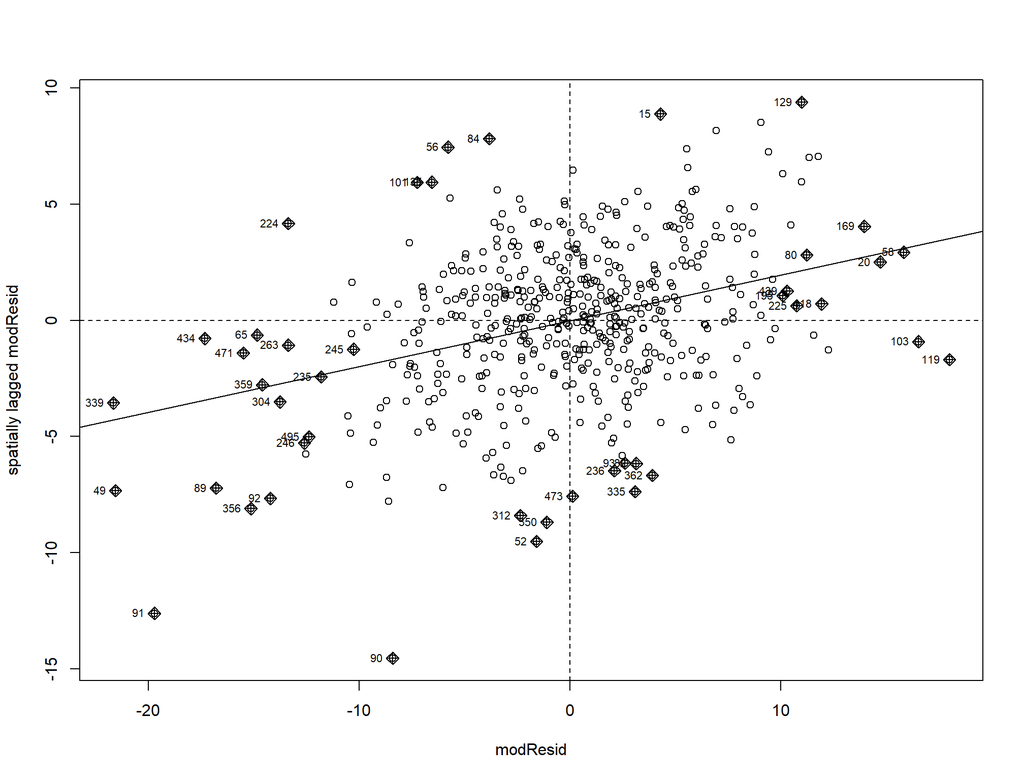

```r
## --- [Step 5] Moran's I test ---
tract.linkW <- nb2listw(tract.link, style = "W")    # row-sum standardized W-coding

spOutliers <- moran.plot(modResid, tract.linkW,
                         labels = rownames(tractShp@data))
```

```r
lm.morantest(mod.final, tract.linkW)                # Moran's I test on regression residuals
```

```
    Global Moran I for regression residuals

data:
model: lm(formula = PctCNwHI ~ log(PERCAPINC) + log(PCTUNIVDEG) +
PCTHISPAN + I(PCTHISPAN^2) + CITYPERI, data = tractShp@data)
weights: tract.linkW

Moran I statistic standard deviate = 7.7791, p-value = 3.653e-15
alternative hypothesis: greater
sample estimates:
Observed Moran I      Expectation         Variance
    0.1970226008    -0.0131863916     0.0007302121
```

The global Moran’s $I$ test applied to the regression residuals of `mod.final` produces a highly significant result. The observed Moran’s $I$ is **0.1970**, with an expected value under $H_0$ of -0.0132 and a variance of 0.000730. This yields a standard deviate of $z(I) = 7.779$ with a p-value < 0.001, which decisively rejects the null hypothesis of spatial independence. The observed Moran’s $I$ is approximately 7.8 standard deviations above its expectation, confirming the presence of **strong positive spatial autocorrelation** in the OLS residuals.

The Moran scatterplot further supports this conclusion. The fitted regression slope through the cloud of points is clearly positive, indicating that tracts with large residuals tend to be surrounded by neighbors whose residuals carry the same sign. Several tracts are flagged by `moran.plot()` as influential observations (marked with filled diamonds) and fall into three distinctive groups:

```r
## Extract the TRACT IDs and attributes of the most prominent
## spatial outliers labeled in the Moran scatterplot.
## Row numbers correspond to the labels visible on the plot.
spOutlierRows <- c(339, 91, 49, 89, 92, 90,   # strong negative-negative cluster
                   15, 129, 169, 20, 58, 80,  # strong positive-positive cluster
                   224,                       # spatial outlier: neg resid, pos neighbors
                   103, 119)                  # spatial outliers: pos resid, neg neighbors
tractShp@data[spOutlierRows, c("TRACT", "CITYPERI", "PctCNwHI")]
```

```
          TRACT   CITYPERI PctCNwHI
339 48113013621 CityDallas 60.87173
91  48113009804 CityDallas 44.54716
49  48113009610 CityDallas 43.05892
89  48113007201 CityDallas 48.31218
92  48113009701 CityDallas 59.62831
90  48113009803 CityDallas 63.90182
15  48113016409 CityDallas 85.39485
129 48113016410       West 94.94670
169 48113005300 CityDallas 80.63902
20  48113016301 CityDallas 84.18242
58  48113013712      North 88.15315
80  48113010602 CityDallas 77.41614
224 48113010101 CityDallas 53.43089
103 48113008603 CityDallas 88.62115
119 48113014501       West 93.06612
```

- **Lower-left quadrant (negative-negative clusters)**: tracts labeled 339, 91, 49, 89, 92, and 90 on the scatterplot all belong to the `CityDallas` subdivision with low `PctCNwHI` values (ranging from roughly 43% to 64%). These represent coldspot areas where the model over-predicts consistently across neighboring tracts.
- **Upper-right quadrant (positive-positive clusters)**: tracts 15, 129, 169, 20, 58, and 80 are the corresponding hotspots of model under-prediction, with high `PctCNwHI` values (ranging from roughly 77% to 95%). These tracts are spread across the `CityDallas`, `West`, and `North` subdivisions.
- **Off-diagonal spatial outliers**: tract 224 (large negative residual surrounded by positive-residual neighbors) and tracts 103 and 119 (large positive residuals surrounded by negative-residual neighbors) are the most noticeable *spatial outliers*. These tracts break the local spatial pattern and typically correspond to isolated tracts whose sign does not match the surrounding ensemble in the bipolar map.

These flagged tracts warrant attention in Task [7] to assess whether the SAR model is able to absorb their residual influence through the $\lambda$ autocorrelation parameter.

### Spatial Correlogram and SAR Suitability

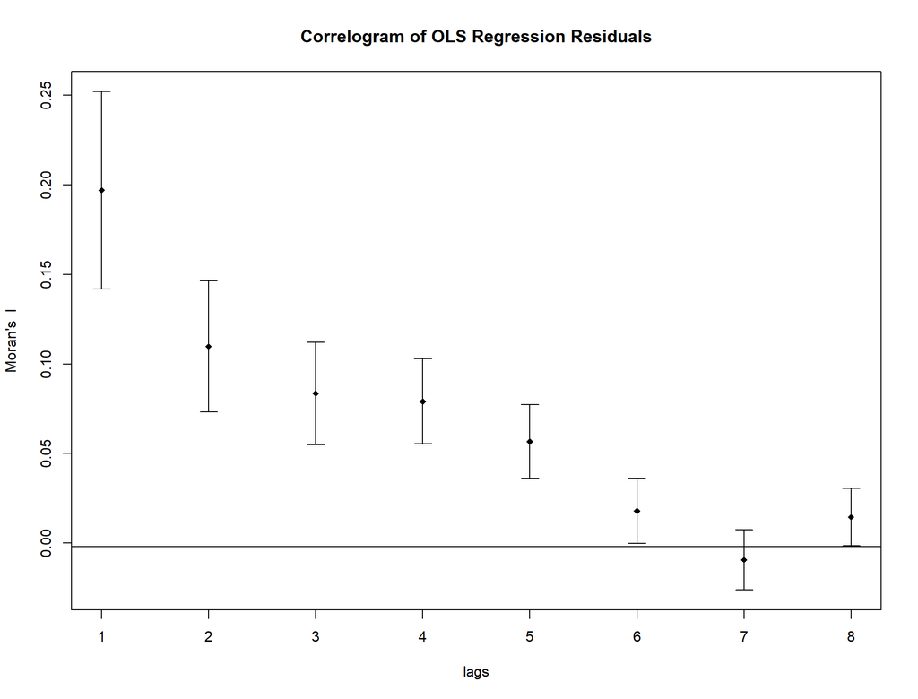

```r
## --- [Step 6] Spatial correlogram ---
plot(sp.correlogram(tract.link, modResid,
                    style = "W", order = 8, method = "I"),
     main = "Correlogram of OLS Regression Residuals")
```

The spatial correlogram, computed using `sp.correlogram()` with `order = 8`, displays the following sequence of Moran’s $I$ values across increasing spatial lags: **0.197** at lag 1, **0.110** at lag 2, **0.083** at lag 3, **0.078** at lag 4, **0.056** at lag 5, **0.017** at lag 6, **-0.009** at lag 7, and **0.013** at lag 8.

The correlogram exhibits a clear **monotonic decay from 0.197 at the first-order lag to essentially zero by the sixth-order lag**. The values at lags 7 and 8 fluctuate marginally around zero, and their 95% error bars already include zero, indicating that Moran’s $I$ is no longer statistically distinguishable from independence at those distances.

This decay pattern **satisfies the theoretical criterion for a first-order simultaneous autoregressive (SAR) process** well. In a SAR process, the spatial autocorrelation is generated by the operator $({\bf I} - \lambda \cdot {\bf V})^{-1}$ acting on independent disturbances $\boldsymbol{\eta}$, which produces an autocorrelation function that declines rapidly across spatial lags but does not abruptly terminate after the first lag. The slight oscillation observed at lags 7–8 is consistent with the pattern described in `SpatialACItaly.rmd` — the script notes that a small oscillation at higher-order lags is “virtually insignificant and can therefore be ignored”. Therefore, proceeding with a first-order SAR specification in Task [7] is appropriate.

### Conclusion and Transition to Task [7]

The spatial analysis of the OLS residuals from `mod.final` confirms three key findings. First, the bipolar residual map displays clear geographic clustering of same-sign residuals, violating the spatial independence assumption of OLS. Second, the global Moran’s $I$ test ($z(I) = 7.78$, $p = 3.65 \times 10^{-15}$) strongly confirms the presence of positive spatial autocorrelation in the residuals. Third, the correlogram shows a rapid monotonic decay of Moran’s $I$ from 0.197 at lag 1 to approximately zero by lag 6, which is consistent with a first-order SAR process.

Therefore, `mod.final` is mis-specified with respect to spatial dependence, and a spatial autoregressive model — specifically the SAR family — will be estimated in Task [7] using `spatialreg::spautolm()`. Since Task [5] concluded that no heteroscedasticity adjustment is required for this dataset, the SAR model will be fit on the 525 census tracts **without** weights.

## Simulanteous Spatial Autoregressive (SAR) Model (2 points)

- Estimation the SAR model, and if necessary the weighted model, with `spatialreg::spautolm( )`.
- Interpret the estimated $\lambda$ autocorrelation coefficient.
- Does the interpretation of the regression coefficients $\beta$ change substantially?
- Check for the possibility of remaining spatial autocorrelation in the SAR residuals with `spdep::moran.mc( )`.

*Your answer goes here*

### SAR Model Estimation

```r
##
## Simultaneous Spatial Autoregressive (SAR) Model
## Note: No weights argument (Task 5 concluded no heteroscedasticity adjustment)
##

## --- [Step 1] Estimate SAR model with same formula as mod.final ---
## Reference: SpatialACItaly.rmd - fert.SAR <- spautolm(..., family="SAR")
tract.SAR <- spautolm(PctCNwHI ~ log(PERCAPINC) + log(PCTUNIVDEG) +
                                  PCTHISPAN + I(PCTHISPAN^2) + CITYPERI,
                      data = tractShp@data,
                      listw = tract.linkW,
                      family = "SAR")
summary(tract.SAR)
```

```
Call: spautolm(formula = PctCNwHI ~ log(PERCAPINC) + log(PCTUNIVDEG) +
    PCTHISPAN + I(PCTHISPAN^2) + CITYPERI, data = tractShp@data,
    listw = tract.linkW, family = "SAR")

Residuals:
       Min         1Q     Median         3Q        Max
-20.867875  -3.017290   0.033887   3.442115  18.297075

Coefficients:
                      Estimate  Std. Error z value  Pr(>|z|)
(Intercept)        12.21318111  9.60184875  1.2720 0.2033868
log(PERCAPINC)      6.56519630  0.99950522  6.5684 5.084e-11
log(PCTUNIVDEG)     2.54844552  0.61700904  4.1303 3.623e-05
PCTHISPAN          -0.28172501  0.04979668 -5.6575 1.536e-08
I(PCTHISPAN^2)      0.00112109  0.00051273  2.1865 0.0287780
CITYPERIEast        2.90016969  1.10696797  2.6199 0.0087950
CITYPERINorth       1.28480176  1.23424545  1.0410 0.2978935
CITYPERIParkCities -0.61489830  2.54969592 -0.2412 0.8094270
CITYPERISouth       5.33766405  1.44107874  3.7039 0.0002123
CITYPERIWest        2.44890563  1.08437559  2.2584 0.0239235

Lambda: 0.43034 LR test value: 48.154 p-value: 3.9395e-12
Numerical Hessian standard error of lambda: 0.056569

Log likelihood: -1631.984
ML residual variance (sigma squared): 28.183, (sigma: 5.3088)
Number of observations: 525
Number of parameters estimated: 12
AIC: 3288
```

```r
## --- [Step 2] Hand-calculated likelihood ratio test ---
(likeH0 <- logLik(mod.final))      # OLS log-likelihood (unweighted)
```

```
'log Lik.' -1656.061 (df=11)
```

```r
(likeH1 <- logLik(tract.SAR))      # SAR log-likelihood
```

```
'log Lik.' -1631.984 (df=12)
```

```r
cat("chi-square value:  ", chi <- -2*(likeH0[1] - likeH1[1]), "\n")
```

```
chi-square value:   48.15434
```

```r
cat("error-probability: ", pchisq(chi, df = 1, lower.tail = FALSE), "\n")
```

```
error-probability:  3.939564e-12
```

The SAR model `tract.SAR` is estimated using `spatialreg::spautolm()` with the same formula as the final OLS model `mod.final` and the row-standardized link matrix `tract.linkW` from Task [6]. No weights are used, consistent with the conclusion in Task [5] that no heteroscedasticity adjustment is warranted. The model converges successfully on all 525 census tracts with no NA issues.

The hand-calculated likelihood ratio test yields a chi-square value of **48.154** with 1 degree of freedom and p-value of **3.94 × 10⁻¹²**, which matches the LR test value reported internally by `summary(tract.SAR)` exactly. The SAR model therefore provides a highly significant improvement over the OLS baseline, which is consistent with the strong spatial autocorrelation detected in Task [6].

**Interpretation of the** $\lambda$ Autocorrelation Coefficient

The estimated spatial autocorrelation parameter is $\lambda = 0.4303$ with a numerical Hessian standard error of 0.0566. The LR test reported in `summary(tract.SAR)` is **48.154 with p = 3.94 × 10⁻¹²**, which strongly rejects the null hypothesis $\lambda = 0$.

The positive sign of $\lambda$ indicates that the process $({\bf I} - \lambda \cdot {\bf V})^{-1}$ acting on the independent disturbances produces **positive spatial spill-over effects** in the observed error term. In other words, after controlling for all exogenous variables in the model, the remaining random variation in `PctCNwHI` at one tract is stochastically tied to the random variation at its neighboring tracts.

### Comparison of OLS and SAR Regression Coefficients

```r
## --- [Step 3] Compare OLS vs SAR coefficients and standard errors ---
## Side-by-side comparison to assess whether beta interpretation changes
ols.coef <- summary(mod.final)$coefficients[, 1:2]   # Estimate, Std. Error
sar.coef <- summary(tract.SAR)$Coef[, 1:2]           # Estimate, Std. Error

coef.comp <- data.frame(
    OLS.Estimate = ols.coef[, 1],
    OLS.StdError = ols.coef[, 2],
    SAR.Estimate = sar.coef[, 1],
    SAR.StdError = sar.coef[, 2]
)
round(coef.comp, 4)
```

```
                   OLS.Estimate OLS.StdError SAR.Estimate SAR.StdError
(Intercept)             12.2292       8.9116      12.2132       9.6018
log(PERCAPINC)           6.9535       0.9528       6.5652       0.9995
log(PCTUNIVDEG)          1.4625       0.6018       2.5484       0.6170
PCTHISPAN               -0.3377       0.0486      -0.2817       0.0498
I(PCTHISPAN^2)           0.0017       0.0005       0.0011       0.0005
CITYPERIEast             2.8606       0.7760       2.9002       1.1070
CITYPERINorth            1.9172       0.8991       1.2848       1.2342
CITYPERIParkCities      -0.4356       2.1575      -0.6149       2.5497
CITYPERISouth            7.1240       1.0823       5.3377       1.4411
CITYPERIWest             2.8380       0.7398       2.4489       1.0844
```

The coefficient magnitudes remain close to the OLS estimates for most predictors:

- `log(PERCAPINC)` decreases slightly from 6.95 to 6.57 (-5.6%)
- `PCTHISPAN` moves from -0.338 to -0.282 (-17%)
- `I(PCTHISPAN^2)` moves from 0.0017 to 0.0011
- `CITYPERIEast` barely changes (2.86 → 2.90)
- `CITYPERIParkCities` remains non-significant

Two coefficients show more noticeable changes. `log(PCTUNIVDEG)` increases from 1.46 to 2.55, and its significance strengthens from p = 0.015 under OLS to p = 3.6 × 10⁻⁵ under SAR. `CITYPERISouth` decreases from 7.12 to 5.34, reflecting that part of the “South” effect previously captured by the factor is now absorbed by the spatial spill-over mechanism.

### Remaining Spatial Autocorrelation in SAR Residuals

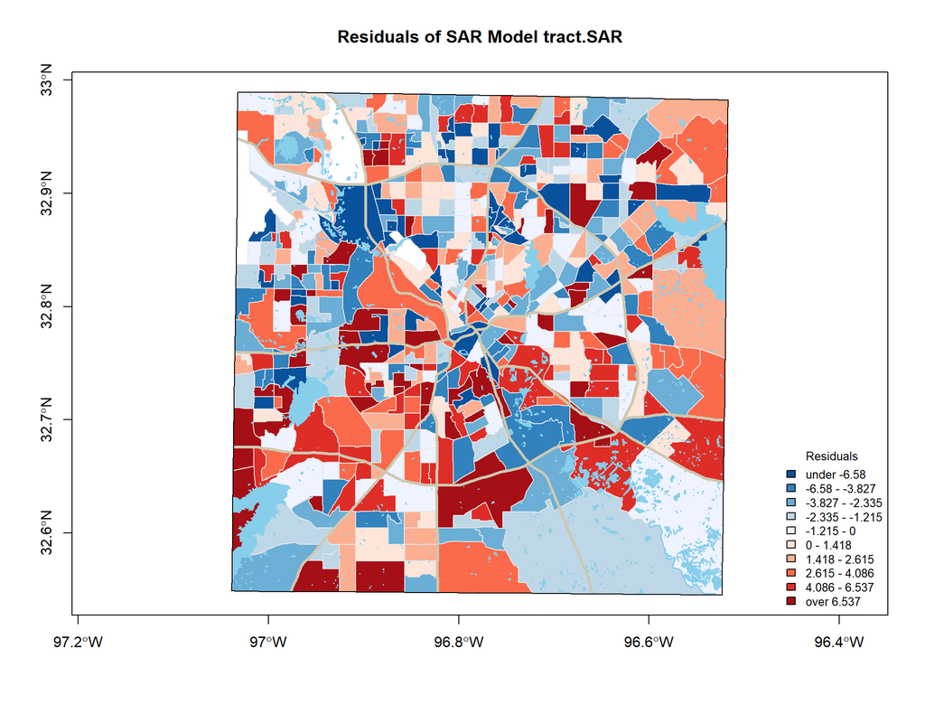

```r
## --- [Step 4] Map SAR residuals ---
SARresid <- residuals(tract.SAR)

## Bipolar map of SAR residuals
mapBiPolar(SARresid, tractShp,
           neg.breaks = 5, pos.breaks = 5, break.value = 0.0,
           map.title    = "Residuals of SAR Model tract.SAR",
           legend.title = "Residuals",
           legend.pos   = "bottomright",
           legend.cex   = 0.8)
plot(lakesShp, col="skyblue", border="skyblue", add=TRUE)
plot(hwyShp,   col="cornsilk3", lwd=3, add=TRUE)
plot(bndShp,   border="black", add=TRUE)
box()
```

```r
## --- [Step 5] Moran's I test on SAR residuals (randomization approach) ---
## ML residuals may not be normally distributed, so use randomization approach
moran.mc(SARresid, tract.linkW, nsim = 9999, alternative = "greater")
```

```
    Monte-Carlo simulation of Moran I

data:  SARresid
weights: tract.linkW
number of simulations + 1: 10000

statistic = -0.02292, observed rank = 2289, p-value = 0.7711
alternative hypothesis: greater
```

The bipolar map of the SAR residuals shows a notably less pronounced clustering pattern compared to the OLS residual map in Task [6]. Some local patches of same-sign residuals can still be observed, but the large contiguous clusters visible in the OLS map are reduced, and the overall distribution of red and blue tracts appears more dispersed across the county.

The formal Moran’s $I$ test on the SAR residuals, performed using the randomization approach with `moran.mc()` and 9,999 simulations, produces:

The observed Moran’s $I$ is very close to zero, and the p-value far exceeds the conventional 0.05 threshold. The null hypothesis of spatial independence in the SAR residuals is therefore accepted. Compared to the OLS residuals in Task [6] where Moran’s $I$ = 0.197 with a standard deviate of 7.779, the spatial autocorrelation has been essentially fully absorbed by the $\lambda$ parameter of the SAR model. Consequently, the SAR model captures the inherent spatial autocorrelation in the Dallas County health insurance coverage data well.